# EST613 - ESTATÍSTICA BAYESIANA LISTA DE EXERCÍCIOS 05

Author

João Paulo Gusmão Teixeira (64316)

1. Considere a integral

$$\int_1^4 4e^{-0,5x} \, dx$$

Pede-se:

1. Calcule o valor exato da integral.
2. Calcule uma aproximação para a integral utilizando o Método do Ponto Médio, considerando a divisão do intervalo $[1,4]$ em 6 subintervalos de mesmo comprimento.
3. Escreva a expressão utilizada para aproximar essa integral por meio da Integração de Monte Carlo, gerando valores aleatórios de uma distribuição Uniforme no intervalo $[1,4]$.
4. Utilizando set.seed(1234), obtenha as estimativas de Monte Carlo da integral para: N=10, N=100, N=100.000. Compare os valores obtidos com o valor exato da integral.

## Resposta 01

### Resposta 01.a) Valor exato

Pelo Teorema Fundamental do Cálculo, preciso de uma primitiva de $f(x) = 4e^{-0,5x}$.

Sabendo que $\int e^{kx}dx = \frac{1}{k}e^{kx}$, com $k = -0,5$:

$$\int 4e^{-0,5x}\,dx = 4 \cdot \frac{1}{-0,5} e^{-0,5x} = -8e^{-0,5x}$$

Aplicando os limites de integração:

$$I = \Big[-8e^{-0,5x}\Big]_1^4 = \left(-8e^{-0,5 \times 4}\right) - \left(-8e^{-0,5 \times 1}\right)$$

$$I = -8e^{-2} + 8e^{-0,5} = 8\left(e^{-0,5} - e^{-2}\right)$$

$$I = 8\,(0,606531 - 0,135335) = 8 \times 0,471195$$

$$I \approx \mathbf{3,769563}$$

```r
# Função a ser integrada
f1 <- function(x) 4 * exp(-0.5 * x)

# Limites de integração
a1 <- 1
b1 <- 4

# Valor exato: 8 * (e^(-0,5) - e^(-2))
I_exato <- 8 * (exp(-0.5) - exp(-2))

# Conferindo com a integração numérica do R
cat("Valor exato:", round(I_exato, 6), "\n")
Valor exato: 3.769563
cat("integrate():", round(integrate(f1, a1, b1)$value, 6), "\n")
integrate(): 3.769563
```

### Resposta 01.b) Método do Ponto Médio

Seguindo o algoritmo do Tópico 6:

**i. Largura de cada subintervalo**, com $k = 6$:

$$\Delta x = \frac{b - a}{k} = \frac{4 - 1}{6} = 0,5$$

**ii. Pontos médios.** O $i$-ésimo ponto médio é dado por $x_i = a + \left(i - \frac{1}{2}\right)\Delta x$:

- $x_1 = 1 + 0,5 \times 0,5 = 1,25$
- $x_2 = 1 + 1,5 \times 0,5 = 1,75$
- $x_3 = 1 + 2,5 \times 0,5 = 2,25$
- $x_4 = 1 + 3,5 \times 0,5 = 2,75$
- $x_5 = 1 + 4,5 \times 0,5 = 3,25$
- $x_6 = 1 + 5,5 \times 0,5 = 3,75$

**iii. e iv. Altura e área de cada retângulo**, com $A_i = \Delta x \cdot f(x_i)$:

| $i$ | $x_i$ | $f(x_i) = 4e^{-0,5x_i}$ | $A_i = 0,5 \cdot f(x_i)$ |
| --- | --- | --- | --- |
| 1 | 1,25 | 2,141046 | 1,070523 |
| 2 | 1,75 | 1,667448 | 0,833724 |
| 3 | 2,25 | 1,298610 | 0,649305 |
| 4 | 2,75 | 1,011358 | 0,505679 |
| 5 | 3,25 | 0,787647 | 0,393823 |
| 6 | 3,75 | 0,613420 | 0,306710 |

**v. Soma das áreas:**

$$I \approx \sum_{i=1}^{6} A_i = 1,070523 + 0,833724 + 0,649305 + 0,505679 + 0,393823 + 0,306710$$

$$I \approx \mathbf{3,759764}$$

```r
k <- 6
dx <- (b1 - a1) / k

# Pontos médios: x_i = a + (i - 1/2) * dx
x_medio <- a1 + (1:k - 0.5) * dx

tabela_pm <- data.frame(
  i = 1:k,
  x_i = x_medio,
  f_xi = f1(x_medio),
  A_i = dx * f1(x_medio)
)
kable(tabela_pm, digits = 6)
```

| i | x_i | f_xi | A_i |
| --- | --- | --- | --- |
| 1 | 1.25 | 2.141046 | 1.070523 |
| 2 | 1.75 | 1.667448 | 0.833724 |
| 3 | 2.25 | 1.298610 | 0.649305 |
| 4 | 2.75 | 1.011358 | 0.505679 |
| 5 | 3.25 | 0.787647 | 0.393823 |
| 6 | 3.75 | 0.613420 | 0.306710 |

```r
I_pm <- sum(tabela_pm$A_i)
erro_pm <- abs(I_pm - I_exato)

cat("Ponto Médio:", round(I_pm, 6), "| Erro absoluto:", round(erro_pm, 6), "\n")
Ponto Médio: 3.759764 | Erro absoluto: 0.009799
```

O Método do Ponto Médio resultou em 3.759764, com um erro de 0.009799 em relação ao valor exato. Mesmo com apenas 6 retângulos, a aproximação já ficou bem próxima do valor real.

### Resposta 01.c) Expressão da Integração de Monte Carlo

A ideia é transformar a integral numa esperança. Multiplicando e dividindo por $(b-a)$:

$$I = \int_1^4 f(x)\,dx = (4 - 1)\int_1^4 \frac{1}{4 - 1} f(x)\,dx$$

Como $\frac{1}{4-1}$ é a f.d.p. de uma $U(1,4)$:

$$I = (4 - 1)\, E_U\left[f(U)\right], \quad U \sim U(1,4)$$

Gerando $u_1, u_2, \dots, u_N \overset{iid}{\sim} U(1,4)$, a esperança é estimada pela média amostral (Lei dos Grandes Números):

$$\boxed{\hat{I}_N = (4 - 1)\,\frac{1}{N}\sum_{i=1}^{N} 4e^{-0,5u_i} = \frac{3}{N}\sum_{i=1}^{N} 4e^{-0,5u_i}}$$

### Resposta 01.d) Estimativas de Monte Carlo

```r
tamanhos <- c(10, 100, 100000)
I_mc <- numeric(length(tamanhos))

for (j in seq_along(tamanhos)) {
  set.seed(1234) # mesma semente para cada N
  u <- runif(tamanhos[j], min = a1, max = b1)
  I_mc[j] <- (b1 - a1) * mean(f1(u))
}

tabela_mc <- data.frame(
  N = fmt(tamanhos),
  Estimativa_MC = I_mc,
  Valor_exato = I_exato,
  Erro_absoluto = abs(I_mc - I_exato)
)
kable(tabela_mc, digits = 6)
```

| N | Estimativa_MC | Valor_exato | Erro_absoluto |
| --- | --- | --- | --- |
| 10 | 3.791638 | 3.769563 | 0.022075 |
| 100 | 4.099535 | 3.769563 | 0.329972 |
| 100.000 | 3.767289 | 3.769563 | 0.002274 |

Com $N = 10$ a estimativa foi 3.7916 e com $N = 100$ foi 4.0995. Com poucos valores, o resultado ainda depende muito de quais $u_i$ foram sorteados (no caso de $N = 100$, o erro inclusive foi maior que com $N = 10$). Com $N = 100.000$ a estimativa foi 3.7673, com erro de apenas 0.0023.

2. Considere a seguinte estrutura de análise bayesiana:

$$Y \sim \text{Binomial}(m, p) \qquad p \sim \text{Beta}(a, b),$$

de modo que:

$$p \mid y \sim \text{Beta}\left(\sum_{i=1}^n y_i + a, \; nm - \sum_{i=1}^n y_i + b\right).$$

Considere $n = 20$, $m = 4$, $\sum_{i=1}^n y_i = 21$, $a = 2$, $b = 5$.

1. Determine $E(p|Y)$ e $V(p|Y)$, isto é, a média e a variância a posteriori, utilizando as propriedades da distribuição Beta.
2. Mostre como $E(p|Y)$ e $V(p|Y)$ podem ser aproximadas por Integração de Monte Carlo, utilizando valores simulados de:
- uma distribuição Uniforme(0,1);
- da distribuição a priori $p \sim \text{Beta}(2,5)$.

Em cada caso, apresente as expressões utilizadas para estimar as quantidades $E(p|Y)$ e $V(p|Y)$.

3. Utilizando set.seed(1234) para N = 1000 valores simulados, obtenha as estimativas de $E(p|Y)$ e $V(p|Y)$ para:
- amostragem pela distribuição Uniforme(0,1);
- amostragem pela distribuição a priori $p \sim \text{Beta}(2,5)$.

Compare os resultados obtidos pelos dois procedimentos com os valores exatos do item (a).

## Resposta 02

### Resposta 02.a) Valores exatos

**Hiperparâmetros da posteriori:**

$$a^* = \sum_{i=1}^n y_i + a = 21 + 2 = \mathbf{23}$$

$$b^* = nm - \sum_{i=1}^n y_i + b = (20 \times 4) - 21 + 5 = 80 - 21 + 5 = \mathbf{64}$$

Logo, $p \mid y \sim \text{Beta}(23, 64)$.

**Média a posteriori:**

$$E(p \mid y) = \frac{a^*}{a^* + b^*} = \frac{23}{23 + 64} = \frac{23}{87} \approx \mathbf{0,264368}$$

**Variância a posteriori:**

$$V(p \mid y) = \frac{a^* b^*}{(a^* + b^*)^2 (a^* + b^* + 1)} = \frac{23 \times 64}{87^2 \times 88}$$

$$V(p \mid y) = \frac{1472}{7569 \times 88} = \frac{1472}{666072} \approx \mathbf{0,002210}$$

```r
# Para ter certeza:
n2 <- 20
m2 <- 4
soma_y2 <- 21
a2 <- 2
b2 <- 5

a2_post <- soma_y2 + a2
b2_post <- n2 * m2 - soma_y2 + b2

E2_exato <- a2_post / (a2_post + b2_post)
V2_exato <- (a2_post * b2_post) / ((a2_post + b2_post)^2 * (a2_post + b2_post + 1))

cat("p | y ~ Beta(", a2_post, ",", b2_post, ")\n")
p | y ~ Beta( 23 , 64 )
cat("E(p|y) =", round(E2_exato, 6), "\n")
E(p|y) = 0.264368
cat("V(p|y) =", round(V2_exato, 6), "\n")
V(p|y) = 0.00221
```

### Resposta 02.b) Expressões de Monte Carlo

Considere $p \in [0, 1]$, com:

- verossimilhança (núcleo): $f(y \mid p) \propto p^{\sum y_i}(1 - p)^{nm - \sum y_i} = p^{21}(1 - p)^{59}$. As constantes $\binom{m}{y_i}$ se cancelam no numerador e no denominador;
- priori: $\pi(p) = \frac{\Gamma(7)}{\Gamma(2)\Gamma(5)}\,p^{2-1}(1-p)^{5-1}$, isto é, $p \sim \text{Beta}(2,5)$.

**Distribuição a posteriori:** pela regra de Bayes,

$$\pi(p \mid y) = \frac{f(y \mid p)\,\pi(p)}{f(y)} = \frac{f(y \mid p)\,\pi(p)}{\int_0^1 f(y \mid p)\,\pi(p)\,dp}$$

**Estimador bayesiano pontual:** a média a posteriori é

$$E(p \mid y) = \int_0^1 p\,\pi(p \mid y)\,dp = \int_0^1 p\,\frac{f(y \mid p)\,\pi(p)}{\int_0^1 f(y \mid p)\,\pi(p)\,dp}\,dp$$

Logo, é preciso aproximar duas integrais: o **denominador** $\int_0^1 f(y \mid p)\,\pi(p)\,dp$ e o **numerador** $\int_0^1 p\,f(y \mid p)\,\pi(p)\,dp$.

#### Caso 1: amostragem pela Uniforme(0,1)

Neste caso, os valores são gerados da distribuição Uniforme: $p_1, \dots, p_N \overset{iid}{\sim} U(0,1)$.

**Aproximação do denominador:** como a densidade da $U(0,1)$ é $\frac{1}{1-0} = 1$,

$$\int_0^1 f(y \mid p)\,\pi(p)\,dp = (1-0)\int_0^1 \frac{1}{1-0}\,f(y \mid p)\,\pi(p)\,dp = (1-0)\,E_U\left[f(Y \mid p)\,\pi(p)\right] \cong \frac{1}{N}\sum_{i=1}^N f(y \mid p_i)\,\pi(p_i)$$

**Aproximação do numerador:** da mesma forma,

$$\int_0^1 p\,f(y \mid p)\,\pi(p)\,dp = (1-0)\,E_U\left[p\,f(Y \mid p)\,\pi(p)\right] \cong \frac{1}{N}\sum_{i=1}^N p_i\,f(y \mid p_i)\,\pi(p_i)$$

**Estimador final:** dividindo o numerador pelo denominador, o fator $\frac{1}{N}$ se cancela:

$$\boxed{\hat{E}(p \mid y) \cong \frac{\sum_{i=1}^N p_i\,f(y \mid p_i)\,\pi(p_i)}{\sum_{i=1}^N f(y \mid p_i)\,\pi(p_i)}}$$

De modo análogo, para $p^2$:

$$\hat{E}(p^2 \mid y) \cong \frac{\sum_{i=1}^N p_i^2\,f(y \mid p_i)\,\pi(p_i)}{\sum_{i=1}^N f(y \mid p_i)\,\pi(p_i)}$$

e a variância a posteriori é estimada por:

$$\boxed{\hat{V}(p \mid y) \cong \frac{\sum_{i=1}^N p_i^2\,f(y \mid p_i)\,\pi(p_i)}{\sum_{i=1}^N f(y \mid p_i)\,\pi(p_i)} - \left[\frac{\sum_{i=1}^N p_i\,f(y \mid p_i)\,\pi(p_i)}{\sum_{i=1}^N f(y \mid p_i)\,\pi(p_i)}\right]^2}$$

#### Caso 2: amostragem pela priori Beta(2,5)

Neste caso, os valores são gerados da própria distribuição a priori: $p_1, \dots, p_N \overset{iid}{\sim} \text{Beta}(2,5)$.

**Denominador da distribuição a posteriori:** como os valores são gerados da própria priori $\pi(p)$, a integral é uma esperança em relação a ela:

$$\int_0^1 f(y \mid p)\,\pi(p)\,dp = \int_0^1 \left[f(y \mid p)\right]\pi(p)\,dp = E_{\pi}\left[f(Y \mid p)\right] \cong \frac{1}{N}\sum_{i=1}^N f(y \mid p_i)$$

**Numerador da média a posteriori:**

$$\int_0^1 p\,f(y \mid p)\,\pi(p)\,dp = \int_0^1 \left[p\,f(y \mid p)\right]\pi(p)\,dp = E_{\pi}\left[p\,f(Y \mid p)\right] \cong \frac{1}{N}\sum_{i=1}^N p_i\,f(y \mid p_i)$$

**A média a posteriori:**

$$\boxed{\hat{E}(p \mid y) \cong \frac{\sum_{i=1}^N p_i\,f(y \mid p_i)}{\sum_{i=1}^N f(y \mid p_i)}}$$

De modo análogo, para $p^2$:

$$\hat{E}(p^2 \mid y) \cong \frac{\sum_{i=1}^N p_i^2\,f(y \mid p_i)}{\sum_{i=1}^N f(y \mid p_i)}$$

e a variância a posteriori é estimada por:

$$\boxed{\hat{V}(p \mid y) \cong \frac{\sum_{i=1}^N p_i^2\,f(y \mid p_i)}{\sum_{i=1}^N f(y \mid p_i)} - \left[\frac{\sum_{i=1}^N p_i\,f(y \mid p_i)}{\sum_{i=1}^N f(y \mid p_i)}\right]^2}$$

A diferença entre os dois casos está apenas no peso de cada $p_i$. Na Uniforme, o peso é $f(y \mid p_i)\,\pi(p_i)$. Na priori, é só $f(y \mid p_i)$, porque a priori já está representada na frequência com que os $p_i$ foram gerados.

### Resposta 02.c) Estimativas com N = 1000

```r
N2 <- 1000

# Núcleo da verossimilhança: p^(soma y) * (1 - p)^(nm - soma y)
veross2 <- function(p) p^soma_y2 * (1 - p)^(n2 * m2 - soma_y2)

# --- Caso 1: Uniforme(0,1) ---
set.seed(1234)
p_unif <- runif(N2, 0, 1)
peso_unif <- veross2(p_unif) * dbeta(p_unif, a2, b2) # L(y|p) * pi(p)

E_unif <- sum(p_unif * peso_unif) / sum(peso_unif)
E2_unif <- sum(p_unif^2 * peso_unif) / sum(peso_unif)
V_unif <- E2_unif - E_unif^2

# --- Caso 2: priori Beta(2,5) ---
set.seed(1234)
p_priori <- rbeta(N2, a2, b2)
peso_priori <- veross2(p_priori) # apenas L(y|p)

E_priori <- sum(p_priori * peso_priori) / sum(peso_priori)
E2_priori <- sum(p_priori^2 * peso_priori) / sum(peso_priori)
V_priori <- E2_priori - E_priori^2

tabela_2c <- data.frame(
  Metodo = c("Valor exato - Beta(23, 64)", "MC - Uniforme(0,1)", "MC - Priori Beta(2,5)"),
  Media = c(E2_exato, E_unif, E_priori),
  Variancia = c(V2_exato, V_unif, V_priori),
  Erro_Media = abs(c(E2_exato, E_unif, E_priori) - E2_exato),
  Erro_Variancia = abs(c(V2_exato, V_unif, V_priori) - V2_exato)
)
kable(tabela_2c, digits = 6)
```

| Metodo | Media | Variancia | Erro_Media | Erro_Variancia |
| --- | --- | --- | --- | --- |
| Valor exato - Beta(23, 64) | 0.264368 | 0.002210 | 0.000000 | 0.000000 |
| MC - Uniforme(0,1) | 0.264869 | 0.002073 | 0.000501 | 0.000137 |
| MC - Priori Beta(2,5) | 0.263763 | 0.002148 | 0.000605 | 0.000062 |

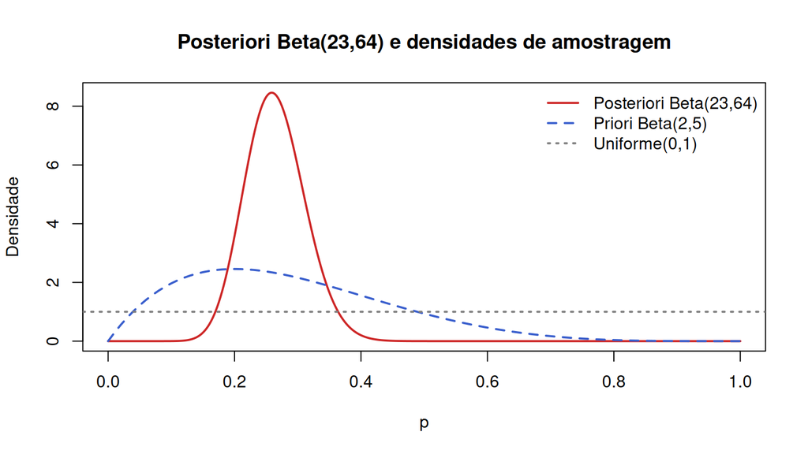

```r
# Visualização: priori, posteriori exata e as duas densidades de amostragem
curve(dbeta(x, a2_post, b2_post), from = 0, to = 1, n = 500, lwd = 2, col = "firebrick3",
      xlab = "p", ylab = "Densidade", main = "Posteriori Beta(23,64) e densidades de amostragem")
curve(dbeta(x, a2, b2), add = TRUE, lwd = 2, col = "royalblue3", lty = 2)
abline(h = 1, lwd = 2, col = "gray50", lty = 3)
legend("topright", legend = c("Posteriori Beta(23,64)", "Priori Beta(2,5)", "Uniforme(0,1)"),
       col = c("firebrick3", "royalblue3", "gray50"), lty = c(1, 2, 3), lwd = 2, bty = "n")
```

Os dois procedimentos chegaram a valores próximos do exato. Para a média, a Uniforme deu 0.2649 e a priori deu 0.2638, contra 0.2644 exato. Para a variância, os valores foram 0.002073 e 0.002148, contra 0.00221.

Pelo gráfico, dá para perceber que a priori Beta(2,5) concentra mais pontos na região em que a posteriori tem massa (em torno de 0,26) do que a Uniforme, que espalha os pontos por todo o intervalo $(0,1)$, inclusive em regiões onde $L(y|p)\pi(p) \approx 0$. Por isso, a amostragem pela priori tende a desperdiçar menos valores, o que se refletiu em um erro menor na variância. Com $N = 1000$, porém, ainda há bastante variação de Monte Carlo nos dois casos.

3. Considere a função densidade de probabilidade

$$f(x) = 6x(1 - x), \quad 0 \leq x \leq 1.$$

Utilize como distribuição candidata $\text{Beta}(2,2)$ e considere $M = 3$.

1. Explique por que a distribuição $\text{Beta}(2,2)$ pode ser utilizada como distribuição candidata.
2. Verifique se a condição $f(x) \leq Mq(x)$ é satisfeita para $M = 3$. O que esse valor de M implica para a taxa teórica de aceitação do método?
3. Determine os valores exatos de $E(X)$ e $V(X)$ da distribuição alvo.
4. Utilize o Método de Aceitação-Rejeição para gerar valores da distribuição alvo e obtenha estimativas para $E(X)$ e $V(X)$.
5. Calcule as taxas observadas de aceitação e rejeição e compare a taxa de aceitação obtida com a taxa teórica esperada.

## Resposta 03

### Resposta 03.a) Por que a Beta(2,2) pode ser candidata

Para ser candidata, a distribuição precisa (i) ser de fácil amostragem, (ii) ter suporte que contenha o suporte da distribuição alvo e (iii) existir $M$ finito tal que $\frac{f(x)}{q(x)} \leq M$.

Escrevendo a f.d.p. da Beta(2,2):

$$q(x) = \frac{\Gamma(2 + 2)}{\Gamma(2)\,\Gamma(2)}\,x^{2-1}(1 - x)^{2-1} = \frac{3!}{1! \times 1!}\,x(1 - x) = 6x(1 - x)$$

Ou seja, $q(x) = f(x)$: a distribuição alvo **é** a própria Beta(2,2). Ela tem o mesmo suporte $[0,1]$, pode ser gerada no R (`rbeta()`) e a razão $\frac{f(x)}{q(x)} = 1$ é limitada, então atende a todas as condições.

### Resposta 03.b) Condição $f(x) \leq Mq(x)$ e taxa teórica

Como $f(x) = q(x)$:

$$M q(x) = 3 \times 6x(1 - x) = 18x(1 - x)$$

$$f(x) \leq Mq(x) \iff 6x(1 - x) \leq 18x(1 - x) \iff 1 \leq 3 \quad \checkmark$$

A condição é satisfeita para todo $x \in [0,1]$. Porém, o menor $M$ possível seria $M = \sup_x \frac{f(x)}{q(x)} = 1$, então $M = 3$ está “folgado”.

A probabilidade de aceitação de cada candidato é:

$$\frac{f(x^*)}{M q(x^*)} = \frac{6x^*(1 - x^*)}{3 \times 6x^*(1 - x^*)} = \frac{1}{3}$$

Logo, a taxa teórica de aceitação é $\frac{1}{M} = \frac{1}{3} \approx \mathbf{0,3333}$ e a de rejeição é $\frac{2}{3} \approx 0,6667$. O número de iterações até a primeira aceitação segue uma Geométrica com $E = M = 3$, ou seja, em média são necessárias 3 propostas para aceitar 1 valor.

### Resposta 03.c) $E(X)$ e $V(X)$ exatos

**Pela integral:**

$$E(X) = \int_0^1 x \cdot 6x(1 - x)\,dx = 6\int_0^1 (x^2 - x^3)\,dx = 6\left[\frac{x^3}{3} - \frac{x^4}{4}\right]_0^1 = 6\left(\frac{1}{3} - \frac{1}{4}\right) = 6 \times \frac{1}{12} = \mathbf{0,5}$$

$$E(X^2) = \int_0^1 x^2 \cdot 6x(1 - x)\,dx = 6\int_0^1 (x^3 - x^4)\,dx = 6\left[\frac{x^4}{4} - \frac{x^5}{5}\right]_0^1 = 6\left(\frac{1}{4} - \frac{1}{5}\right) = \frac{6}{20} = 0,3$$

$$V(X) = E(X^2) - [E(X)]^2 = 0,3 - 0,5^2 = 0,3 - 0,25 = \mathbf{0,05}$$

**Conferindo pelas propriedades da Beta(2,2):**

$$E(X) = \frac{\alpha}{\alpha + \beta} = \frac{2}{4} = 0,5 \qquad V(X) = \frac{\alpha\beta}{(\alpha + \beta)^2(\alpha + \beta + 1)} = \frac{4}{16 \times 5} = 0,05$$

### Resposta 03.d) Método de Aceitação-Rejeição

```r
set.seed(1234)

f_alvo <- function(x) 6 * x * (1 - x) # f(x)
M3 <- 3

N3 <- 10000            # número de valores aceitos desejados
x_aceitos <- numeric(N3)
l <- 0                 # contador de aceitos
total <- 0             # contador de propostas

while (l < N3) {
  total <- total + 1

  # i. candidato da Beta(2,2)
  x_star <- rbeta(1, shape1 = 2, shape2 = 2)

  # ii. valor da Uniforme(0,1)
  u <- runif(1)

  # iii. aceita se u <= f(x*) / (M q(x*))
  if (u <= f_alvo(x_star) / (M3 * dbeta(x_star, 2, 2))) {
    l <- l + 1
    x_aceitos[l] <- x_star
  }
}

E3_ar <- mean(x_aceitos)
V3_ar <- var(x_aceitos)

kable(data.frame(
  Quantidade = c("E(X)", "V(X)"),
  Exato = c(0.5, 0.05),
  Aceitacao_Rejeicao = c(E3_ar, V3_ar)
), digits = 6)
```

| Quantidade | Exato | Aceitacao_Rejeicao |
| --- | --- | --- |
| E(X) | 0.50 | 0.500078 |
| V(X) | 0.05 | 0.049204 |

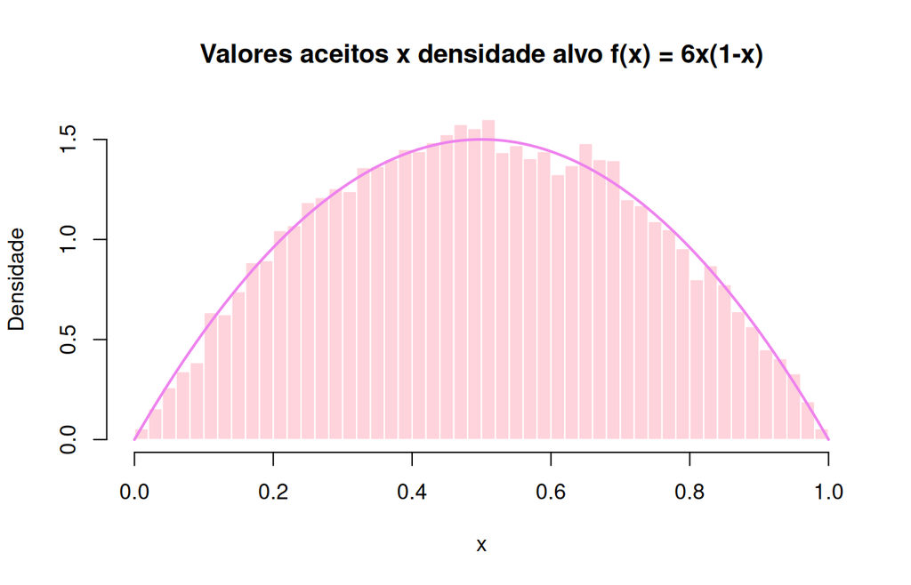

```r
hist(x_aceitos, breaks = 40, probability = TRUE, col = adjustcolor("pink", alpha.f = 0.7),
     border = "white", main = "Valores aceitos x densidade alvo f(x) = 6x(1-x)",
     xlab = "x", ylab = "Densidade")
curve(f_alvo(x), add = TRUE, lwd = 2, col = "violet")
```

Com 10.000 valores aceitos, as estimativas foram $\hat{E}(X) =$ 0.5001 e $\hat{V}(X) =$ 0.0492, bem próximas dos valores exatos 0,5 e 0,05. O histograma dos aceitos acompanha a curva de $f(x)$.

### Resposta 03.e) Taxas de aceitação e rejeição

```r
tx_aceite <- N3 / total
tx_rejeicao <- 1 - tx_aceite

cat("Total de propostas:", total, "\n")
Total de propostas: 30173
cat("Taxa de aceitação observada:", round(tx_aceite, 4), "| teórica:", round(1 / M3, 4), "\n")
Taxa de aceitação observada: 0.3314 | teórica: 0.3333
cat("Taxa de rejeição observada:", round(tx_rejeicao, 4), "| teórica:", round(1 - 1 / M3, 4), "\n")
Taxa de rejeição observada: 0.6686 | teórica: 0.6667
```

Foram necessárias 30.173 propostas para obter 10.000 aceitos. A taxa de aceitação observada foi 0.3314 e a de rejeição 0.6686, praticamente iguais às teóricas $\frac{1}{3}$ e $\frac{2}{3}$. Isso mostra que, quando o $M$ é maior do que o necessário, o algoritmo continua correto.

4. Existem três marcas de cerveja, designadas por A, B e C, de grande consumo. Um estudo de mercado revelou o seguinte comportamento dos consumidores de uma semana para a semana seguinte:

Consumidores fiéis:

- à marca A: 80%;
- à marca B: 75%;
- à marca C: 95%.

Consumidores que mudam de marca:

- entre os que consumiram B na semana anterior, 5% passam a consumir A;
- entre os que consumiram C na semana anterior, 2% passam a consumir A;
- entre os que consumiram A na semana anterior, 15% passam a consumir B;
- entre os que consumiram C na semana anterior, 3% passam a consumir B;
- entre os que consumiram A na semana anterior, 5% passam a consumir C;
- entre os que consumiram B na semana anterior, 20% passam a consumir C.

Considere que a escolha da marca ao longo das semanas pode ser representada por uma Cadeia de Markov.

1. Determine a matriz de transição do processo, considerando a ordem dos estados A, B e C.
2. Suponha que, na semana atual, 50% dos consumidores consumam a cerveja A, nenhum consumidor consuma a cerveja B e 50% consumam a cerveja C. Determine a distribuição percentual dos consumidores entre as três marcas na próxima semana.
3. Utilizando o software R ou outra linguagem de programação, determine a distribuição estacionária da cadeia.
4. Partindo da distribuição inicial apresentada no item (b), determine a primeira iteração em que a distribuição da cadeia pode ser considerada suficientemente próxima da distribuição estacionária, adotando o critério

$$\max_j \left|\pi_j^{(t)} - \pi_j^*\right| < 10^{-6},$$

em que $\pi_j^{(t)}$ é a distribuição na iteração t e $\pi_j^*$ é a distribuição estacionária.

## Resposta 04

### Resposta 04.a) Matriz de transição

Cada linha representa a marca consumida na semana atual e cada coluna a marca da semana seguinte, com $p_{ij} = P(X_{t} = j \mid X_{t-1} = i)$:

- Linha A: fica em A (80%), vai para B (15%), vai para C (5%)
- Linha B: vai para A (5%), fica em B (75%), vai para C (20%)
- Linha C: vai para A (2%), vai para B (3%), fica em C (95%)

$$P = \begin{pmatrix} 0,80 & 0,15 & 0,05 \\ 0,05 & 0,75 & 0,20 \\ 0,02 & 0,03 & 0,95 \end{pmatrix}$$

Conferindo que cada linha soma 1: $0,80 + 0,15 + 0,05 = 1$; $0,05 + 0,75 + 0,20 = 1$; $0,02 + 0,03 + 0,95 = 1$. $\checkmark$

```r
P <- matrix(c(0.80, 0.15, 0.05,
              0.05, 0.75, 0.20,
              0.02, 0.03, 0.95),
            nrow = 3, byrow = TRUE)
rownames(P) <- colnames(P) <- c("A", "B", "C")

P
     A    B    C
A 0.80 0.15 0.05
B 0.05 0.75 0.20
C 0.02 0.03 0.95
rowSums(P)
A B C
1 1 1
```

### Resposta 04.b) Distribuição na próxima semana

A distribuição atual é $\pi^{(0)} = (0,50;\; 0;\; 0,50)$. Pela relação $\pi^{(1)} = \pi^{(0)} P$:

$$\pi^{(1)}_A = 0,50 \times 0,80 + 0 \times 0,05 + 0,50 \times 0,02 = 0,40 + 0 + 0,01 = \mathbf{0,41}$$

$$\pi^{(1)}_B = 0,50 \times 0,15 + 0 \times 0,75 + 0,50 \times 0,03 = 0,075 + 0 + 0,015 = \mathbf{0,09}$$

$$\pi^{(1)}_C = 0,50 \times 0,05 + 0 \times 0,20 + 0,50 \times 0,95 = 0,025 + 0 + 0,475 = \mathbf{0,50}$$

Na próxima semana, 41% dos consumidores estarão com a marca A, 9% com a B e 50% com a C ($0,41 + 0,09 + 0,50 = 1$).

```r
pi0 <- c(A = 0.5, B = 0, C = 0.5)
pi1 <- pi0 %*% P
round(pi1 * 100, 2)
      A B  C
[1,] 41 9 50
```

### Resposta 04.c) Distribuição estacionária

A distribuição estacionária satisfaz $\pi^* = \pi^* P$ com $\pi_A^* + \pi_B^* + \pi_C^* = 1$. Escrevendo o sistema:

$$\pi_A^* = 0,80\pi_A^* + 0,05\pi_B^* + 0,02\pi_C^*$$

$$\pi_B^* = 0,15\pi_A^* + 0,75\pi_B^* + 0,03\pi_C^*$$

$$\pi_A^* + \pi_B^* + \pi_C^* = 1$$

Que é equivalente a $(P^\top - I)\,\pi^* = 0$, substituindo a última equação (redundante) pela restrição de soma 1, como feito no Módulo 5.

```r
A_sist <- t(P) - diag(3)
A_sist[3, ] <- c(1, 1, 1) # restrição: soma = 1
b_sist <- c(0, 0, 1)

pi_est <- solve(A_sist, b_sist)
names(pi_est) <- colnames(P)

round(pi_est, 6)
       A        B        C
0.112069 0.155172 0.732759

# Verificação: pi* P deve ser igual a pi*
round(as.numeric(pi_est %*% P), 6)
[1] 0.112069 0.155172 0.732759
```

A distribuição estacionária é $\pi^* \approx$ (0.1121; 0.1552; 0.7328). No longo prazo, cerca de 11.21% dos consumidores ficam com a marca A, 15.52% com a B e 73.28% com a C. A marca C domina o mercado por ter a maior fidelidade (95%).

Esses valores correspondem às frações exatas $\pi^* = \left(\frac{13}{116};\; \frac{18}{116};\; \frac{85}{116}\right)$.

### Resposta 04.d) Iteração de convergência

```r
tol <- 1e-6
pi_t <- pi0
t_iter <- 0
dist_max <- c()

repeat {
  t_iter <- t_iter + 1
  pi_t <- pi_t %*% P
  dist_max[t_iter] <- max(abs(pi_t - pi_est))
  if (dist_max[t_iter] < tol) break
}

cat("Primeira iteração com max|pi(t) - pi*| < 1e-6: t =", t_iter, "\n")
Primeira iteração com max|pi(t) - pi*| < 1e-6: t = 66
cat("Distância nessa iteração:", signif(dist_max[t_iter], 4), "\n")
Distância nessa iteração: 8.912e-07
cat("Distância na iteração anterior:", signif(dist_max[t_iter - 1], 4), "\n")
Distância na iteração anterior: 1.091e-06
round(pi_t, 6)
            A        B        C
[1,] 0.112069 0.155173 0.732758
```

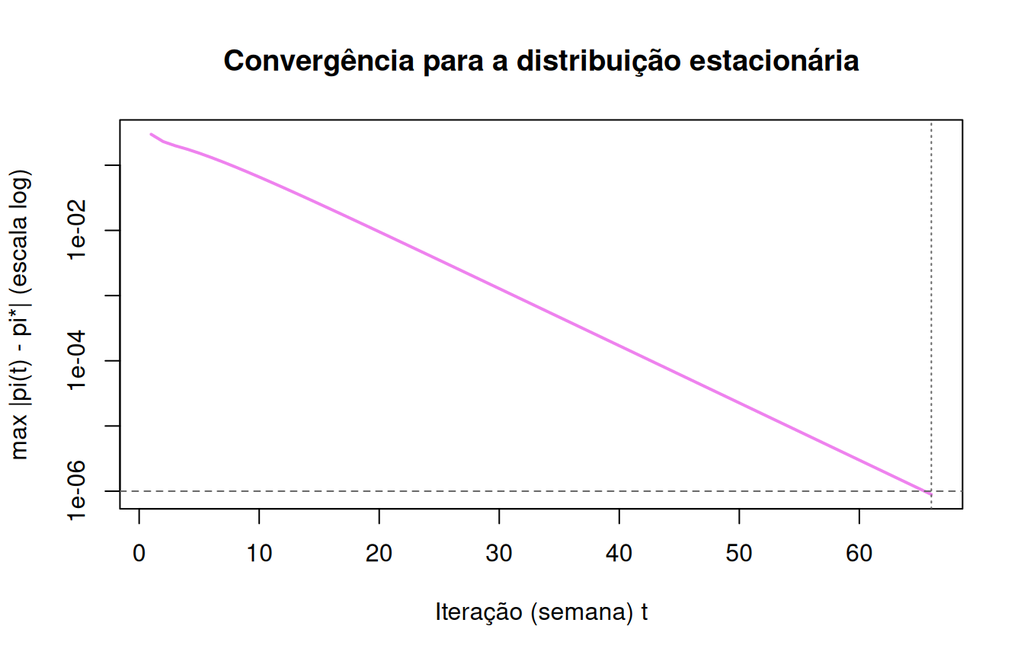

```r
plot(1:t_iter, dist_max, type = "l", lwd = 2, col = "violet", log = "y",
     xlab = "Iteração (semana) t", ylab = "max |pi(t) - pi*| (escala log)",
     main = "Convergência para a distribuição estacionária")
abline(h = tol, lty = 2, col = "gray40")
abline(v = t_iter, lty = 3, col = "gray40")
```

Partindo de $\pi^{(0)} = (0,5;\; 0;\; 0,5)$, a cadeia satisfaz o critério $\max_j |\pi_j^{(t)} - \pi_j^*| < 10^{-6}$ pela primeira vez na iteração **t = 66**. No gráfico (escala log), a distância cai de forma praticamente linear, o que indica convergência geométrica para $\pi^*$.

5. Explique, em termos gerais, por que a convergência das cadeias MCMC (Markov chain Monte Carlo) é fundamental para que as amostras geradas possam ser utilizadas para fazer inferência sobre a distribuição a posteriori. Comente também o que pode acontecer quando a cadeia ainda não atingiu a região de equilíbrio.

## Resposta 05

A ideia central do MCMC é construir uma cadeia de Markov cuja **distribuição estacionária** seja exatamente a posteriori $\pi(\theta \mid y)$. Tal qual vimos no exercício 4, a distribuição da cadeia só se aproxima de $\pi^*$ depois de um certo número de iterações, ou seja, os primeiros valores ainda “lembram” o ponto de partida.

Só depois da convergência é que cada valor gerado pode ser considerado uma amostra da posteriori. Nesse ponto, as médias, quantis e intervalos calculados com os valores da cadeia passam a estimar as quantidades da posteriori.

Quando a cadeia ainda não atingiu a região de equilíbrio:

- os valores ainda carregam a influência do **valor inicial**, e as estimativas ficam **viesadas** (por exemplo, a média fica puxada para o chute inicial);
- a variabilidade pode ser subestimada ou superestimada, pois a cadeia pode estar presa em uma região do espaço paramétrico e não ter explorado toda a posteriori (por exemplo, apenas uma das modas de uma posteriori bimodal);
- cadeias iniciadas em pontos diferentes dão resultados diferentes, sinal de que nenhuma delas representa a posteriori;
- os intervalos de credibilidade e o HPD ficam incorretos, e as conclusões da análise ficam comprometidas.

Por isso se deve usar o burn-in e os diagnósticos de convergência antes de usar as amostras.

6. Explique a importância do burn-in, do thinning (thin) e do tamanho efetivo da amostra (ESS) em uma análise MCMC, destacando o papel de cada um na qualidade das amostras geradas e na precisão das estimativas a posteriori.

## Resposta 06

**Burn-in:** é o descarte das primeiras iterações da cadeia, período em que ela ainda está “saindo” do valor inicial e caminhando para a região de equilíbrio. Descartar esse trecho evita o viés causado pelo valor inicial.

**Thinning (thin):** é guardar apenas um valor a cada $k$ iterações, com o objetivo de reduzir a autocorrelação entre os valores armazenados e economizar memória. De qualquer maneira, de modo geral é preferível rodar mais iterações a fazer thinning.

**Tamanho efetivo da amostra (ESS):** como os valores da cadeia são autocorrelacionados, $N$ valores dependentes carregam menos informação do que $N$ valores independentes. O ESS indica a quantos valores **independentes** a cadeia equivale. Pode-se ter um $N$ grande, mas com valores extremamente autocorrelacionados, o que daria um $ESS$ baixo. Essa cadeia seria menos informativa do que uma com $N$ menos, mas $ESS$ maior.

7. Considere duas cadeias MCMC para o mesmo parâmetro. A primeira apresenta alta autocorrelação entre valores consecutivos e ESS igual a 250. A segunda apresenta baixa autocorrelação e ESS igual a 2.500, embora ambas tenham o mesmo número total de iterações.
1. Qual das cadeias apresenta melhor mistura? Justifique.
2. Qual delas fornece maior quantidade de informação efetiva?
3. Em qual cadeia se espera menor erro de Monte Carlo?
4. Explique por que o número total de iterações, isoladamente, não é suficiente para avaliar a qualidade de uma cadeia MCMC.

## Resposta 07

### Resposta 07.a)

A **segunda cadeia** tem melhor mistura. Baixa autocorrelação significa que a cadeia “anda” rapidamente pelo espaço paramétrico, isto é, valores consecutivos são pouco dependentes e ela percorre toda a posteriori em poucas iterações. Na primeira, a alta autocorrelação mostra que ela se move devagar, com passos pequenos ou muitas rejeições, e demora a explorar a posteriori.

### Resposta 07.b)

A **segunda cadeia**. Com o mesmo número de iterações, ela equivale a 2.500 valores independentes, contra apenas 250 da primeira, ou seja, 10 vezes mais informação efetiva.

### Resposta 07.c)

Na **segunda cadeia**. Considerando a mesma posteriori (mesmo $DP(\theta \mid y)$):

$$\frac{MCSE_1}{MCSE_2} = \frac{DP/\sqrt{250}}{DP/\sqrt{2500}} = \sqrt{\frac{2500}{250}} = \sqrt{10} \approx 3,16$$

O erro de Monte Carlo da primeira cadeia é cerca de 3,16 vezes maior que o da segunda.

### Resposta 07.d)

Porque o número de iterações não leva em conta a **dependência** entre os valores nem se a cadeia **convergiu**. Como vimos neste exercício, duas cadeias com o mesmo número de iterações podem ter quantidades de informação muito diferentes (ESS de 250 e de 2.500). Além disso, uma cadeia com muitas iterações pode:

- ainda não ter convergido (por exemplo, valor inicial ruim e burn-in insuficiente);
- estar presa em uma região da posteriori (por exemplo, em uma das modas);
- ter alta autocorrelação, resultando em ESS baixo.

Por isso, é necessário avaliar as demais métricas (autocorreção, ESS, diagnósticos de convergência e afins)

8. Compare os algoritmos Gibbs Sampler e Metropolis-Hastings, destacando:
- como os novos valores dos parâmetros são gerados em cada método;
- o papel das distribuições condicionais completas;
- a existência ou não de etapa de aceitação/rejeição;
- em quais situações cada algoritmo é mais apropriado.

## Resposta 08

| Aspecto | Gibbs Sampler | Metropolis-Hastings |
| --- | --- | --- |
| **Geração dos novos valores** | Cada parâmetro é sorteado, um de cada vez, diretamente da sua distribuição condicional completa, dados os valores mais recentes dos demais: $\theta_1^{(t)} \sim \pi(\theta_1 \mid \theta_2^{(t-1)}, \do… | Um valor candidato $\theta^*$ é gerado de uma distribuição proposta $q(\theta^* \mid \theta^{(t-1)})$ (por exemplo, um passeio aleatório Normal centrado no valor atual). |
| **Condicionais completas** | São essenciais: é preciso conhecê-las e saber gerar valores delas (geralmente, famílias conhecidas obtidas por conjugação condicional). | Não são necessárias. Basta conhecer a posteriori **a menos de uma constante**, $\pi(\theta \mid y) \propto L(y \mid \theta)\pi(\theta)$, pois a constante se cancela na razão. |
| **Aceitação/rejeição** | Não há: todo valor gerado é aceito (taxa de aceitação = 1). Ele pode ser visto como um caso particular do M-H em que a proposta é a própria condicional completa. | Há: o candidato é aceito com probabilidade $\alpha = \min\left\{1, \frac{\pi(\theta^* \mid y)\, q(\theta^{(t-1)} \mid \theta^*)}{\pi(\theta^{(t-1)} \mid y)\, q(\theta^* \mid \theta^{(t-1)})}\right\}$.… |
| **Quando usar** | Quando as condicionais completas são de famílias conhecidas (modelos conjugados ou condicionalmente conjugados, como o Normal com $\mu$ e $\sigma^2$ do Módulo 5). Pode ficar lento quando os parâmetros… | Quando as condicionais não têm forma conhecida, por exemplo, com prioris não conjugadas ou modelos não lineares. Exige calibrar a proposta: passos muito pequenos geram alta autocorrelação, e passos mu… |

9. Realize uma análise bayesiana completa para o modelo especificado abaixo, utilizando o software R em conjunto com OpenBUGS, JAGS ou Stan, ou outra linguagem/programa apropriado.

Considere o seguinte modelo:

$$Y \sim \text{Poisson}(\theta)$$

com distribuição a priori

$$\theta \sim \text{Gama}(shape, rate)$$

Os dados observados são:

$$y = (13, 16, 11, 8, 9, 10, 8, 9, 6, 10, 10, 5, 10, 14, 3, 10, 9, 10, 10, 16)$$

Considere as seguintes situações:

| Distribuição a priori pouco informativa | Distribuição a priori informativa |
| --- | --- |
| shape = 0,001 | shape = 100 |
| rate = 0,001 | rate = 10 |

Para cada situação, execute duas cadeias MCMC, utilizando valores iniciais distintos, e responda:

1. Informe o número total de iterações, o período de burn-in/warm-up e, caso seja utilizado, o valor de thin. Justifique brevemente as escolhas realizadas.
2. Informe os valores iniciais utilizados em cada uma das duas cadeias.
3. Apresente os trace plots das duas cadeias e interprete seu comportamento quanto à estabilidade, mistura e exploração da distribuição a posteriori.
4. Apresente os gráficos de autocorrelação das cadeias. Comente o grau de dependência entre as amostras e a velocidade de redução da autocorrelação ao longo dos lags.
5. Avalie a convergência das cadeias utilizando os critérios de diagnóstico estudados na disciplina e interprete os resultados obtidos.
6. Apresente o Tamanho Efetivo da Amostra (ESS) do parâmetro e interprete o resultado em relação ao número total de valores simulados.
7. Obtenha as estimativas a posteriori do parâmetro, apresentando: média; mediana; variância; coeficiente de variação; intervalo de credibilidade de 95%; intervalo HPD de 95%.
8. Apresente o gráfico da distribuição marginal a posteriori do parâmetro.
9. Com base no gráfico e nas medidas obtidas anteriormente, discuta se a distribuição a posteriori apresenta simetria ou assimetria. Justifique sua conclusão.
10. Compare os resultados obtidos com as duas distribuições a priori. Discuta a influência da escolha da priori sobre a distribuição a posteriori e sobre as estimativas do parâmetro.

## Resposta 09

### Posteriori analítica (para conferência)

Antes de partir para o MCMC, vale lembrar que a Gama é conjugada da Poisson, então a posteriori exata é conhecida e servirá para conferir o resultado das cadeias.

**Verossimilhança:**

$$L(\theta \mid y) = \prod_{i=1}^n \frac{e^{-\theta}\theta^{y_i}}{y_i!} \propto \theta^{\sum y_i} e^{-n\theta}$$

**Priori:**

$$\pi(\theta) = \frac{b^a}{\Gamma(a)}\theta^{a-1}e^{-b\theta} \propto \theta^{a-1}e^{-b\theta}$$

**Posteriori:**

$$\pi(\theta \mid y) \propto \theta^{\sum y_i}e^{-n\theta} \times \theta^{a-1}e^{-b\theta} = \theta^{\left(\sum y_i + a\right) - 1}e^{-(n + b)\theta}$$

$$\theta \mid y \sim \text{Gama}\left(\sum y_i + a, \; n + b\right)$$

Com os dados: $n = 20$ e $\sum y_i = 13 + 16 + 11 + 8 + 9 + 10 + 8 + 9 + 6 + 10 + 10 + 5 + 10 + 14 + 3 + 10 + 9 + 10 + 10 + 16 = 197$ ($\bar{y} = 9,85$).

- **Priori pouco informativa**, Gama(0,001; 0,001): $\theta \mid y \sim \text{Gama}(197,001;\; 20,001)$, com $E(\theta \mid y) = \frac{197,001}{20,001} \approx 9,8496$ e $V(\theta \mid y) = \frac{197,001}{20,001^2} \approx 0,4925$
- **Priori informativa**, Gama(100; 10): $\theta \mid y \sim \text{Gama}(297;\; 30)$, com $E(\theta \mid y) = \frac{297}{30} = 9,9$ e $V(\theta \mid y) = \frac{297}{30^2} = 0,33$

### Ajuste no Stan

Escolhi o Stan, pois ele já está instalado na minha máquina, e o Módulo 5 trouxe o procedimento. O modelo segue a parametrização Gama(shape, rate), a mesma do R (`dgamma(x, shape, rate)`).

```r
y9 <- c(13, 16, 11, 8, 9, 10, 8, 9, 6, 10, 10, 5, 10, 14, 3, 10, 9, 10, 10, 16)

modelo9_code <- "
data {
  int<lower=1> n;
  array[n] int<lower=0> y;
  real<lower=0> shape;
  real<lower=0> rate;
}
parameters {
  real<lower=0> theta;
}
model {
  // Priori
  theta ~ gamma(shape, rate);
  // Verossimilhança
  y ~ poisson(theta);
}
"

modelo9 <- stan_model(model_code = modelo9_code)

# Configurações das cadeias (iguais para as duas prioris)
n_cadeias <- 2
n_iter <- 11000   # iterações totais por cadeia
n_warmup <- 1000  # warm-up (burn-in) por cadeia
n_thin <- 1       # sem thinning
inits9 <- list(list(theta = 1), list(theta = 25))

ajustar9 <- function(shape, rate) {
  sampling(
    object = modelo9,
    data = list(n = length(y9), y = y9, shape = shape, rate = rate),
    chains = n_cadeias, iter = n_iter, warmup = n_warmup, thin = n_thin,
    init = inits9, seed = 1234, refresh = 0
  )
}

fit_pi <- ajustar9(shape = 0.001, rate = 0.001) # pouco informativa
fit_inf <- ajustar9(shape = 100, rate = 10)     # informativa

# Objetos coda (sem o warm-up)
mcmc_pi <- As.mcmc.list(fit_pi, pars = "theta")
mcmc_inf <- As.mcmc.list(fit_inf, pars = "theta")

print(fit_pi, pars = "theta", probs = c(0.025, 0.5, 0.975))
Inference for Stan model: anon_model.
2 chains, each with iter=11000; warmup=1000; thin=1;
post-warmup draws per chain=10000, total post-warmup draws=20000.

      mean se_mean  sd 2.5%  50% 97.5% n_eff Rhat
theta 9.84    0.01 0.7 8.52 9.83 11.25  7523    1

Samples were drawn using NUTS(diag_e) at Sat Nov 21 12:08:00 2026.
For each parameter, n_eff is a crude measure of effective sample size,
and Rhat is the potential scale reduction factor on split chains (at
convergence, Rhat=1).
print(fit_inf, pars = "theta", probs = c(0.025, 0.5, 0.975))
Inference for Stan model: anon_model.
2 chains, each with iter=11000; warmup=1000; thin=1;
post-warmup draws per chain=10000, total post-warmup draws=20000.

      mean se_mean   sd 2.5%  50% 97.5% n_eff Rhat
theta  9.9    0.01 0.58  8.8 9.89 11.07  7509    1

Samples were drawn using NUTS(diag_e) at Sat Nov 21 12:08:00 2026.
For each parameter, n_eff is a crude measure of effective sample size,
and Rhat is the potential scale reduction factor on split chains (at
convergence, Rhat=1).
```

### Resposta 09.a) Iterações, warm-up e thin

Para as duas prioris usei:

- **Iterações totais:** 11.000 por cadeia, totalizando 22.000 iterações;
- **Warm-up (burn-in):** 1.000 por cadeia. No Stan, essa fase também serve para adaptar o tamanho do passo e a matriz de massa do NUTS;
- **Thin:** 1, ou seja, sem thinning;
- **Amostras finais:** $(11.000 - 1.000) \times 2 =$ 20.000 valores.

Justificativa: o modelo tem apenas um parâmetro e a posteriori é unimodal e bem comportada, então o NUTS converge rápido. 1.000 iterações de warm-up são mais do que suficientes para a cadeia sair dos valores iniciais (que escolhi propositalmente longe da posteriori) e para a adaptação do algoritmo. As 10.000 iterações pós-warm-up por cadeia garantem um ESS alto (ver item f) e atendem ao número mínimo sugerido pelo diagnóstico de Raftery-Lewis (item e), que, num primeiro teste com 5.000 iterações por cadeia, pediu entre 6.000 e 8.300 iterações. Não usei thinning porque a autocorrelação cai rapidamente (item d), e, como visto no Módulo 5, descartar valores só reduziria a informação.

### Resposta 09.b) Valores iniciais

| Cadeia | Valor inicial de $\theta$ | Justificativa |
| --- | --- | --- |
| 1 | 1 | bem abaixo de $\bar{y} = 9,85$ |
| 2 | 25 | bem acima de $\bar{y} = 9,85$ |

Os mesmos valores iniciais foram usados nas duas situações de priori. Escolhi valores dispersos, em lados opostos da posteriori, para que o diagnóstico de Gelman-Rubin tenha sentido: se as cadeias partem de pontos distantes e chegam à mesma região, há evidência de convergência.

### Resposta 09.c) Trace plots

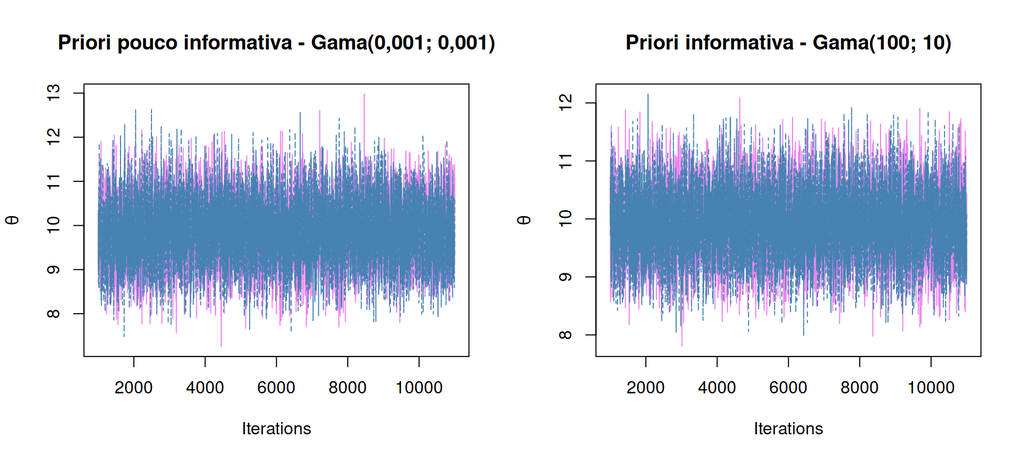

```r
par(mfrow = c(1, 2))
coda::traceplot(mcmc_pi, col = c("violet", "steelblue"),
                main = "Priori pouco informativa - Gama(0,001; 0,001)", ylab = expression(theta))
coda::traceplot(mcmc_inf, col = c("violet", "steelblue"),
                main = "Priori informativa - Gama(100; 10)", ylab = expression(theta))
```

```r
par(mfrow = c(1, 1))
```

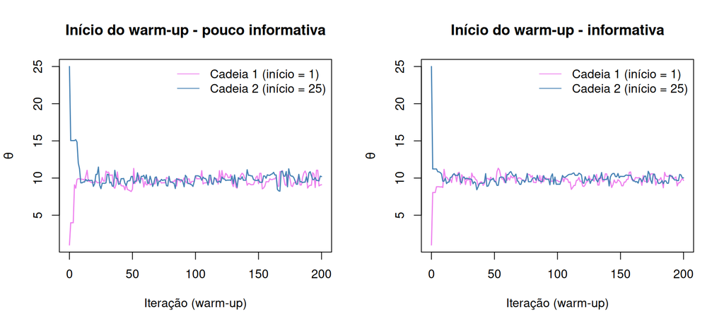

```r
# Primeiras 200 iterações INCLUINDO o warm-up, para ver a saída dos valores iniciais
trace_warmup <- function(fit, titulo) {
  arr <- rstan::extract(fit, pars = "theta", permuted = FALSE, inc_warmup = TRUE)
  # O Stan não guarda o valor inicial junto com os sorteios: incluo como iteração 0
  cadeias <- rbind(c(1, 25), arr[1:200, , 1])
  matplot(0:200, cadeias, type = "l", lty = 1, lwd = 1.5,
          col = c("violet", "steelblue"), xlab = "Iteração (warm-up)",
          ylab = expression(theta), main = titulo)
  legend("topright", legend = c("Cadeia 1 (início = 1)", "Cadeia 2 (início = 25)"),
         col = c("violet", "steelblue"), lty = 1, bty = "n")
}

par(mfrow = c(1, 2))
trace_warmup(fit_pi, "Início do warm-up - pouco informativa")
trace_warmup(fit_inf, "Início do warm-up - informativa")
```

```r
par(mfrow = c(1, 1))
```

No segundo gráfico, dá para ver que as duas cadeias saem dos valores iniciais (1 e 25) e chegam à região de $\theta \approx 10$ logo nas primeiras iterações do warm-up. Depois do warm-up (primeiro gráfico), nas duas situações de priori:

- **Estabilidade:** as cadeias oscilam em torno de um mesmo valor central (≈ 9,8 a 9,9), sem tendência de subida ou descida;
- **Mistura:** as duas cadeias se sobrepõem completamente, aparecem como uma “faixa” densa, sem trechos em que uma cadeia fica parada ou presa;
- **Exploração:** elas percorrem toda a amplitude da posteriori várias vezes, indo e voltando às caudas.

Também é possível perceber que a faixa da priori informativa é um pouco mais estreita, já que a posteriori tem variância menor.

### Resposta 09.d) Autocorrelação

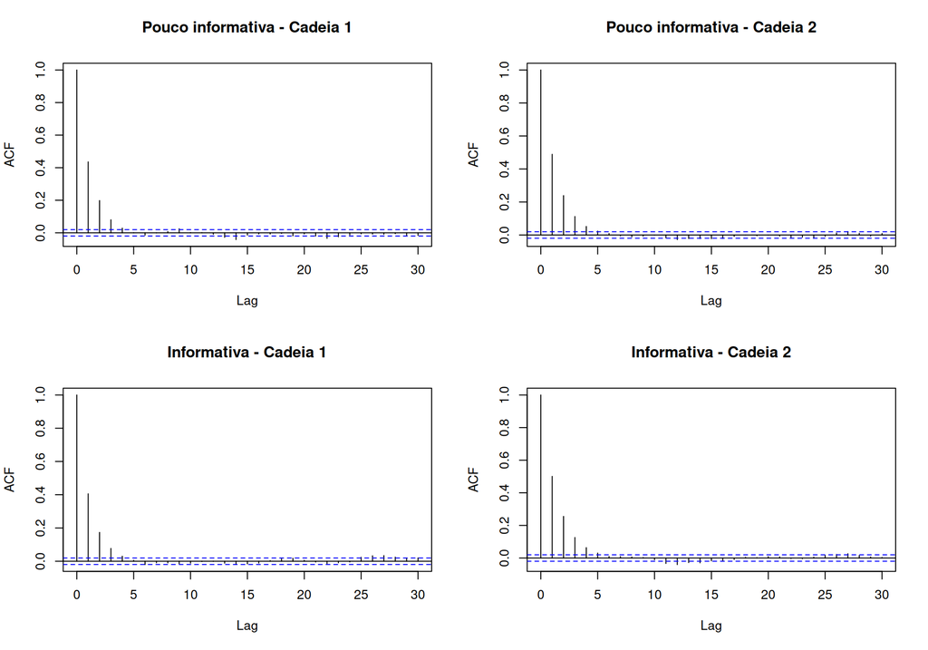

```r
par(mfrow = c(2, 2))
acf(as.numeric(mcmc_pi[[1]]), lag.max = 30, main = "Pouco informativa - Cadeia 1")
acf(as.numeric(mcmc_pi[[2]]), lag.max = 30, main = "Pouco informativa - Cadeia 2")
acf(as.numeric(mcmc_inf[[1]]), lag.max = 30, main = "Informativa - Cadeia 1")
acf(as.numeric(mcmc_inf[[2]]), lag.max = 30, main = "Informativa - Cadeia 2")
```

```r
par(mfrow = c(1, 1))
```

```r
autocorr.diag(mcmc_pi, lags = c(1, 2, 5, 10))
              theta
Lag 1  0.4623173767
Lag 2  0.2184089759
Lag 5  0.0118808164
Lag 10 0.0003148939
autocorr.diag(mcmc_inf, lags = c(1, 2, 5, 10))
             theta
Lag 1   0.45318982
Lag 2   0.21437546
Lag 5   0.01785009
Lag 10 -0.01124247
```

A autocorrelação no lag 1 é moderada (≈ 0.46 na pouco informativa e ≈ 0.45 na informativa), mas cai rapidamente: a partir do lag 3 a 5, os valores já ficam dentro das bandas de significância (linhas tracejadas), ou seja, praticamente zero. Isso mostra que a dependência entre as amostras é fraca e de curta duração, o que confirma que não há necessidade de thinning.

### Resposta 09.e) Diagnósticos de convergência

```r
diagnosticos <- function(fit, ml) {
  sp <- get_sampler_params(fit, inc_warmup = FALSE)
  cat("--- R-hat (Stan):", round(summary(fit, pars = "theta")$summary[, "Rhat"], 4), "\n")
  cat("--- Divergências:", sum(sapply(sp, function(x) sum(x[, "divergent__"]))), "\n\n")
  cat("--- Gelman-Rubin\n");         print(gelman.diag(ml))
  cat("--- Geweke (escores Z)\n");   print(sapply(geweke.diag(ml), function(g) g$z))
  cat("\n--- Heidelberger-Welch\n"); print(heidel.diag(ml))
  cat("--- Raftery-Lewis\n");        print(raftery.diag(ml))
}

# Escores Z do Geweke guardados para o texto
gw_pi <- sapply(geweke.diag(mcmc_pi), function(g) g$z)
gw_inf <- sapply(geweke.diag(mcmc_inf), function(g) g$z)

cat("========== PRIORI POUCO INFORMATIVA ==========\n")
========== PRIORI POUCO INFORMATIVA ==========
diagnosticos(fit_pi, mcmc_pi)
--- R-hat (Stan): 1
--- Divergências: 0

--- Gelman-Rubin
Potential scale reduction factors:

      Point est. Upper C.I.
theta          1          1

--- Geweke (escores Z)
       theta        theta
-0.006438502 -2.933924517

--- Heidelberger-Welch
[[1]]

      Stationarity start     p-value
      test         iteration
theta passed       1         0.632

      Halfwidth Mean Halfwidth
      test
theta passed    9.85 0.021

[[2]]

      Stationarity start     p-value
      test         iteration
theta passed       1         0.189

      Halfwidth Mean Halfwidth
      test
theta passed    9.84 0.0236

--- Raftery-Lewis
[[1]]

Quantile (q) = 0.025
Accuracy (r) = +/- 0.005
Probability (s) = 0.95

       Burn-in  Total Lower bound  Dependence
       (M)      (N)   (Nmin)       factor (I)
 theta 7        7604  3746         2.03


[[2]]

Quantile (q) = 0.025
Accuracy (r) = +/- 0.005
Probability (s) = 0.95

       Burn-in  Total Lower bound  Dependence
       (M)      (N)   (Nmin)       factor (I)
 theta 5        5672  3746         1.51

cat("\n========== PRIORI INFORMATIVA ==========\n")

========== PRIORI INFORMATIVA ==========
diagnosticos(fit_inf, mcmc_inf)
--- R-hat (Stan): 1.0002
--- Divergências: 0

--- Gelman-Rubin
Potential scale reduction factors:

      Point est. Upper C.I.
theta          1          1

--- Geweke (escores Z)
     theta      theta
-0.1937481 -2.0445457

--- Heidelberger-Welch
[[1]]

      Stationarity start     p-value
      test         iteration
theta passed       1         0.255

      Halfwidth Mean Halfwidth
      test
theta passed    9.9  0.0175

[[2]]

      Stationarity start     p-value
      test         iteration
theta passed       1         0.112

      Halfwidth Mean Halfwidth
      test
theta passed    9.9  0.0195

--- Raftery-Lewis
[[1]]

Quantile (q) = 0.025
Accuracy (r) = +/- 0.005
Probability (s) = 0.95

       Burn-in  Total Lower bound  Dependence
       (M)      (N)   (Nmin)       factor (I)
 theta 6        8270  3746         2.21


[[2]]

Quantile (q) = 0.025
Accuracy (r) = +/- 0.005
Probability (s) = 0.95

       Burn-in  Total Lower bound  Dependence
       (M)      (N)   (Nmin)       factor (I)
 theta 5        6130  3746         1.64
```

Interpretando cada critério (os resultados foram semelhantes para as duas prioris):

- **Gelman-Rubin ($\hat{R}$):** compara a variância entre cadeias com a variância dentro das cadeias. Os valores ficaram em 1 (pouco informativa) e 1 (informativa), com limite superior ≤ 1,01, ou seja, abaixo de 1,1 (ou do critério mais rígido, 1,01). As duas cadeias, mesmo partindo de 1 e 25, convergiram para a mesma distribuição.
- **Geweke:** compara a média dos primeiros 10% com a dos últimos 50% de cada cadeia; se $|Z| > 1,96$, há indício de que a cadeia não está estacionária. Na cadeia 1, os escores ficaram dentro do intervalo, mas na cadeia 2 eles ficaram fora: Z = -2.93 (pouco informativa) e Z = -2.04 (informativa). Esse resultado é discutido logo abaixo.
- **Heidelberger-Welch:** todas as cadeias passaram no teste de estacionariedade e no teste de meia-amplitude (halfwidth), indicando que a média está estimada com precisão suficiente.
- **Raftery-Lewis:** para estimar o quantil 0,025 com precisão de ± 0,005, o burn-in sugerido (M) é de poucas iterações e o número total sugerido (N) é menor que as 10.000 iterações usadas por cadeia. O fator de dependência (I) ficou abaixo de 5, o que indica baixa autocorrelação.
- **Diagnósticos do NUTS:** zero divergências, então não houve problemas numéricos nas trajetórias Hamiltonianas.

Como o Geweke acusou a cadeia 2, fui verificar o tamanho dessa diferença entre o início e o fim da cadeia:

```r
# Médias das janelas usadas pelo Geweke (10% iniciais e 50% finais) em cada cadeia
janelas_geweke <- function(ml) {
  t(sapply(seq_along(ml), function(j) {
    x <- as.numeric(ml[[j]])
    n <- length(x)
    inicio <- mean(x[1:floor(0.1 * n)])
    final <- mean(x[(floor(0.5 * n) + 1):n])
    c(Cadeia = j, Media_10_inicio = inicio, Media_50_final = final,
      Diferenca = inicio - final, Dif_em_DP_post = (inicio - final) / sd(unlist(ml)))
  }))
}

kable(janelas_geweke(mcmc_pi), digits = 4, caption = "Priori pouco informativa")
```

Priori pouco informativa

| Cadeia | Media_10_inicio | Media_50_final | Diferenca | Dif_em_DP_post |
| --- | --- | --- | --- | --- |
| 1 | 9.8552 | 9.8553 | -0.0001 | -0.0001 |
| 2 | 9.7178 | 9.8449 | -0.1271 | -0.1810 |

```r
kable(janelas_geweke(mcmc_inf), digits = 4, caption = "Priori informativa")
```

Priori informativa

| Cadeia | Media_10_inicio | Media_50_final | Diferenca | Dif_em_DP_post |
| --- | --- | --- | --- | --- |
| 1 | 9.9085 | 9.9129 | -0.0044 | -0.0077 |
| 2 | 9.8280 | 9.9071 | -0.0791 | -0.1368 |

Na cadeia 2, a média dos 10% iniciais ficou entre 0,08 e 0,13 abaixo da média dos 50% finais, o que equivale a menos de 20% do desvio-padrão da posteriori (coluna `Dif_em_DP_post`). O teste acusa porque, com milhares de valores, mesmo diferenças pequenas ficam “significativas”, e ele tem 5% de chance de rejeitar mesmo quando a cadeia está estacionária. Além disso, as duas cadeias 2 usam a mesma semente, então os dois alarmes não são independentes entre si.

Considerando que o Gelman-Rubin, o Heidelberger-Welch (que também testa a estacionariedade, e passou em todas as cadeias) e a comparação com a posteriori exata (item g) não indicam problema, interpreto o resultado do Geweke como um falso alarme, e não como falta de convergência. Mesmo assim, é um bom exemplo de que nenhum diagnóstico deve ser olhado isoladamente.

Conclusão: há evidência de convergência nas duas situações, e as amostras podem ser usadas para inferência.

### Resposta 09.f) Tamanho Efetivo da Amostra (ESS)

```r
n_total <- (n_iter - n_warmup) * n_cadeias

ess_pi <- effectiveSize(mcmc_pi)
ess_inf <- effectiveSize(mcmc_inf)

mcse_pi <- sd(as.matrix(mcmc_pi)) / sqrt(ess_pi)
mcse_inf <- sd(as.matrix(mcmc_inf)) / sqrt(ess_inf)

kable(data.frame(
  Priori = c("Pouco informativa", "Informativa"),
  N_total = n_total,
  ESS = c(ess_pi, ess_inf),
  ESS_relativo = c(ess_pi, ess_inf) / n_total,
  MCSE = c(mcse_pi, mcse_inf)
), digits = 4)
```

| Priori | N_total | ESS | ESS_relativo | MCSE |
| --- | --- | --- | --- | --- |
| Pouco informativa | 20000 | 7682.387 | 0.3841 | 0.0080 |
| Informativa | 20000 | 7554.558 | 0.3777 | 0.0067 |

Dos 20.000 valores simulados, o ESS foi de 7682 (pouco informativa) e 7555 (informativa), ou seja, cerca de 38% e 38% do total. A perda em relação a $N$ vem da autocorrelação moderada do lag 1, mas o ESS ainda é bem alto. Com isso, o erro padrão de Monte Carlo da média ficou em torno de 0.008, muito pequeno em relação ao desvio-padrão da posteriori. A precisão é mais do que suficiente para estimar médias, quantis e intervalos.

### Resposta 09.g) Estimativas a posteriori

```r
resumo_post <- function(amostras) {
  ic <- quantile(amostras, c(0.025, 0.975))
  hpd <- hdi(amostras, credMass = 0.95)
  c(Media = mean(amostras),
    Mediana = median(amostras),
    Variancia = var(amostras),
    CV_perc = 100 * sd(amostras) / mean(amostras),
    IC_inf = unname(ic[1]), IC_sup = unname(ic[2]),
    HPD_inf = unname(hpd[1]), HPD_sup = unname(hpd[2]))
}

theta_pi <- as.numeric(as.matrix(mcmc_pi))
theta_inf <- as.numeric(as.matrix(mcmc_inf))

res_pi <- resumo_post(theta_pi)
res_inf <- resumo_post(theta_inf)

# Valores exatos das posterioris conjugadas, para conferência
exato9 <- function(sh, rt) c(Media = sh / rt, Mediana = qgamma(0.5, sh, rt), Variancia = sh / rt^2,
                             CV_perc = 100 / sqrt(sh), IC_inf = qgamma(0.025, sh, rt),
                             IC_sup = qgamma(0.975, sh, rt),
                             HPD_inf = hdi(qgamma, 0.95, shape = sh, rate = rt)[1],
                             HPD_sup = hdi(qgamma, 0.95, shape = sh, rate = rt)[2])

tabela9 <- rbind(
  "MCMC - pouco informativa" = res_pi,
  "Exato - Gama(197,001; 20,001)" = exato9(0.001 + sum(y9), 0.001 + length(y9)),
  "MCMC - informativa" = res_inf,
  "Exato - Gama(297; 30)" = exato9(100 + sum(y9), 10 + length(y9))
)
kable(tabela9, digits = 4)
```

|  | Media | Mediana | Variancia | CV_perc | IC_inf | IC_sup | HPD_inf | HPD_sup |
| --- | --- | --- | --- | --- | --- | --- | --- | --- |
| MCMC - pouco informativa | 9.8439 | 9.8293 | 0.4930 | 7.1328 | 8.5185 | 11.2492 | 8.5068 | 11.2309 |
| Exato - Gama(197,001; 20,001) | 9.8496 | 9.8329 | 0.4925 | 7.1247 | 8.5221 | 11.2717 | 8.4904 | 11.2369 |
| MCMC - informativa | 9.8984 | 9.8865 | 0.3341 | 5.8394 | 8.7952 | 11.0724 | 8.7738 | 11.0430 |
| Exato - Gama(297; 30) | 9.9000 | 9.8889 | 0.3300 | 5.8026 | 8.8060 | 11.0571 | 8.7846 | 11.0341 |

| Medida | Pouco informativa | Informativa |
| --- | --- | --- |
| Média | 9.8439 | 9.8984 |
| Mediana | 9.8293 | 9.8865 |
| Variância | 0.493 | 0.3341 |
| Coeficiente de variação | 7.13% | 5.84% |
| IC 95% | [8.519; 11.249] | [8.795; 11.072] |
| HPD 95% | [8.507; 11.231] | [8.774; 11.043] |

As estimativas do MCMC ficaram muito próximas das obtidas analiticamente pela posteriori conjugada, o que valida a simulação.

### Resposta 09.h) Distribuição marginal a posteriori

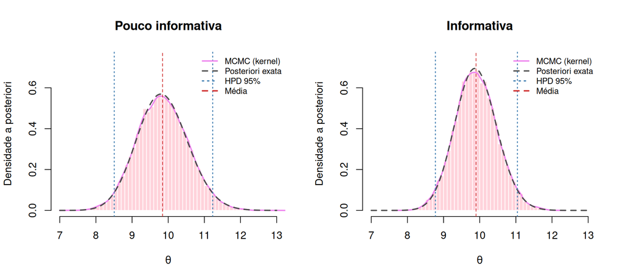

```r
grafico_post <- function(amostras, sh, rt, titulo, res) {
  hist(amostras, breaks = 50, probability = TRUE, col = adjustcolor("pink", alpha.f = 0.7),
       border = "white", main = titulo, xlab = expression(theta),
       ylab = "Densidade a posteriori", xlim = c(7, 13), ylim = c(0, 0.75))
  lines(density(amostras), lwd = 2, col = "violet")
  curve(dgamma(x, shape = sh, rate = rt), add = TRUE, lwd = 2, lty = 2, col = "gray30")
  abline(v = res[c("HPD_inf", "HPD_sup")], lty = 3, col = "steelblue", lwd = 1.5)
  abline(v = res["Media"], lty = 2, col = "firebrick3")
  legend("topright", legend = c("MCMC (kernel)", "Posteriori exata", "HPD 95%", "Média"),
         col = c("violet", "gray30", "steelblue", "firebrick3"), lty = c(1, 2, 3, 2),
         lwd = 2, bty = "n", cex = 0.8)
}

par(mfrow = c(1, 2))
grafico_post(theta_pi, 197.001, 20.001, "Pouco informativa", res_pi)
grafico_post(theta_inf, 297, 30, "Informativa", res_inf)
```

```r
par(mfrow = c(1, 1))
```

### Resposta 09.i) Simetria ou assimetria

As duas posterioris são **aproximadamente simétricas**, com uma **leve assimetria à direita**. Os argumentos:

- **Gráfico:** a forma é de sino, bem parecida com uma Normal centrada em ≈ 9,85 a 9,9;
- **Média e mediana** quase iguais: 9.8439 e 9.8293 (pouco informativa); 9.8984 e 9.8865 (informativa). A média ligeiramente maior que a mediana indica a cauda direita um pouco mais longa;
- **IC e HPD** quase coincidentes. Em uma distribuição perfeitamente simétrica, eles seriam iguais. O HPD aparece levemente deslocado para a esquerda em relação ao IC de caudas iguais (como vimos na Lista 4 para a Gama);
- **Teoricamente**, a assimetria da Gama é $\frac{2}{\sqrt{\text{shape}}}$: $\frac{2}{\sqrt{197}} \approx 0,14$ e $\frac{2}{\sqrt{297}} \approx 0,12$, valores pequenos e positivos.

Como o shape da posteriori é grande (muitos dados: $\sum y_i = 197$), a Gama se aproxima da Normal, e a assimetria é quase imperceptível.

### Resposta 09.j) Comparação entre as prioris

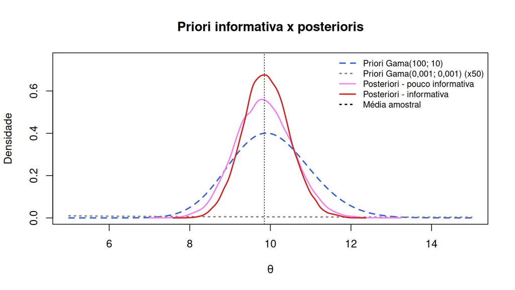

```r
curve(dgamma(x, 100, 10), from = 5, to = 15, n = 500, lwd = 2, lty = 2, col = "royalblue3",
      xlab = expression(theta), ylab = "Densidade", ylim = c(0, 0.75),
      main = "Priori informativa x posterioris")
curve(dgamma(x, 0.001, 0.001) * 50, add = TRUE, lwd = 2, lty = 3, col = "gray50") # escala ampliada
lines(density(theta_pi), lwd = 2, col = "violet")
lines(density(theta_inf), lwd = 2, col = "firebrick3")
abline(v = mean(y9), lty = 3)
legend("topright", legend = c("Priori Gama(100; 10)", "Priori Gama(0,001; 0,001) (x50)",
                              "Posteriori - pouco informativa", "Posteriori - informativa",
                              "Média amostral"),
       col = c("royalblue3", "gray50", "violet", "firebrick3", "black"),
       lty = c(2, 3, 1, 1, 3), lwd = 2, bty = "n", cex = 0.8)
```

**Priori pouco informativa**, Gama(0,001; 0,001): tem média $\frac{0,001}{0,001} = 1$, mas variância enorme ($\frac{0,001}{0,001^2} = 1000$), sendo praticamente plana na região de interesse. Os hiperparâmetros somam quase nada aos dados ($197 + 0,001$ e $20 + 0,001$), então a posteriori é praticamente a verossimilhança normalizada: a média a posteriori (9.844) ≈ $\bar{y} = 9,85$.

**Priori informativa**, Gama(100; 10): tem média $\frac{100}{10} = 10$ e variância $\frac{100}{10^2} = 1$. Ela equivale a ter observado **10 observações anteriores** (rate = 10) somando 100 (shape = 100). A média a posteriori é uma média ponderada entre a média a priori e a média amostral:

$$E(\theta \mid y) = \frac{a + \sum y_i}{b + n} = \underbrace{\frac{b}{b + n}}_{10/30}\cdot\frac{a}{b} + \underbrace{\frac{n}{b + n}}_{20/30}\cdot\bar{y} = \frac{1}{3}(10) + \frac{2}{3}(9,85) = 9,9$$

Os dados têm peso de 2/3 e a priori de 1/3. Como a priori estava centrada em 10, perto de $\bar{y}$, ela não “puxou” muito a estimativa (9,85 → 9,9). O efeito maior foi na **incerteza**: a variância caiu de 0.493 para 0.334 (≈ 32% menor), e o HPD ficou mais estreito (amplitude 2.724 contra 2.269).

Em resumo: com $n = 20$, os dados dominam a posteriori nas duas situações, mas a priori informativa adiciona informação equivalente a 10 observações e aumenta a precisão. Se a priori informativa estivesse centrada longe de $\bar{y}$, ela deslocaria a estimativa, o que mostra a importância de justificar bem a escolha da priori.

10. Neste exercício, utilize a variável aleatória Y escolhida nas listas anteriores e proponha um modelo bayesiano em que pelo menos uma das distribuições a priori seja não conjugada à verossimilhança. Realize a análise bayesiana utilizando métodos MCMC e responda:
1. Especifique as distribuições a priori atribuídas aos parâmetros, identificando qual delas é não conjugada e justificando as escolhas realizadas.
2. Apresente a formulação do modelo no software, pacote ou linguagem de programação utilizado.
3. Informe o número total de iterações, o período de burn-in/warm-up e, caso seja utilizado, o thinning. Justifique as escolhas realizadas.
4. Informe os valores iniciais utilizados para os parâmetros em cada cadeia.
5. Apresente os trace plots das cadeias e discuta seu comportamento quanto à estabilidade, mistura e exploração da distribuição a posteriori.
6. Apresente os gráficos das cadeias (traceplot).
7. Apresente os gráficos de autocorrelação das cadeias e interprete os resultados.
8. Avalie a convergência das cadeias utilizando os critérios estudados na disciplina e interprete os resultados obtidos.
9. Apresente o Tamanho Efetivo da Amostra (ESS) dos parâmetros e interprete os resultados.
11. Obtenha as estimativas a posteriori do parâmetro, apresentando: média; mediana; variância; coeficiente de variação; intervalo de credibilidade de 95%; intervalo HPD de 95%.
10. Apresente os gráficos das distribuições marginais a posteriori dos parâmetros.
11. Comente sobre a forma das distribuições marginais a posteriori, incluindo a presença de simetria ou assimetria, quando pertinente.
12. Explique por que, no modelo proposto, a escolha da priori não conjugada torna a obtenção analítica da distribuição a posteriori mais difícil e justifique o uso de métodos MCMC.

## Resposta 10

Primeiramente, uma recapitulação da variável escolhida nas listas anteriores.

**NoteContexto da Pesquisa (Exercício 15 da Lista I e Questão 5 da Lista III)**

- **Variável Aleatória ($Y_i$):** Número de locos marcadores do tipo SNP em homozigose num painel de $m = 50$ marcadores bialélicos independentes avaliados no $i$-ésimo indivíduo de uma população sob melhoramento.
- **Modelo dos Dados:** $Y_i \mid p \overset{\text{i.i.d.}}{\sim} \text{Binomial}(m = 50, \, p)$ para $i = 1, \dots, n$.
- **Parâmetro de Interesse:** $p \in (0, 1)$, que representa a probabilidade de homozigose por loco genômico.
- **Priori conjugada usada na Lista III:** $p \sim \text{Beta}(11, 9)$.

```r
# Mesma simulação da Lista I (Resposta 15l)
set.seed(50)
N_sim <- 1000
n_par <- 50
p_par <- 0.60
amostra_sim <- rbinom(n = N_sim, size = n_par, prob = p_par)

soma_y10 <- sum(amostra_sim)
cat("n =", N_sim, "| m =", n_par, "| soma y =", soma_y10,
    "| p chapéu =", round(soma_y10 / (N_sim * n_par), 4), "\n")
n = 1000 | m = 50 | soma y = 30179 | p chapéu = 0.6036
```

### Resposta 10.a) Distribuição a priori não conjugada

Na Lista III usei a priori conjugada $p \sim \text{Beta}(11, 9)$. Agora, em vez de colocar a priori diretamente em $p$, vou trabalhar na escala logit, que é muito usada em genética e em modelos lineares generalizados:

$$\eta = \text{logit}(p) = \log\left(\frac{p}{1 - p}\right) \quad \Longleftrightarrow \quad p = \frac{e^{\eta}}{1 + e^{\eta}}$$

**Priori não conjugada:**

$$\eta \sim N(\mu_0, \sigma_0^2) \quad \Longleftrightarrow \quad p \sim \text{Logit-Normal}(\mu_0, \sigma_0^2)$$

Essa priori **não é conjugada** à Binomial: a verossimilhança é escrita em $p = \frac{e^\eta}{1 + e^\eta}$, e o produto com o núcleo Normal em $\eta$ não resulta em nenhuma família conhecida (ver item l).

**Justificativas:**

- $\eta$ pode assumir qualquer valor real, então a Normal é natural para ele, e a transformação logit garante que $p$ continue no intervalo $(0, 1)$ (preserva o espaço paramétrico);
- na escala logit, o efeito de outros fatores (por exemplo, geração de autofecundação ou linhagem) poderia ser adicionado de forma linear, o que facilitaria ampliar o modelo depois.

**Definição dos hiperparâmetros:** para manter a mesma informação a priori da Lista III (média de endogamia ≈ 0,55, que havia sido justificada com base no histórico da população), escolhi $\mu_0$ e $\sigma_0$ de modo que a Logit-Normal tenha a mesma média e variância que a Beta(11, 9) teria **na escala logit**. Se $p \sim \text{Beta}(a, b)$, então:

$$E[\text{logit}(p)] = \psi(a) - \psi(b) \qquad V[\text{logit}(p)] = \psi'(a) + \psi'(b)$$

em que $\psi$ é a função digama e $\psi'$ a trigama. Com $a = 11$ e $b = 9$:

$$\mu_0 = \psi(11) - \psi(9) = \frac{1}{9} + \frac{1}{10} \approx 0,2111$$

$$\sigma_0^2 = \psi'(11) + \psi'(9) \approx 0,0952 + 0,1175 = 0,2127 \implies \sigma_0 \approx 0,4612$$

Portanto:

$$\boxed{\eta = \text{logit}(p) \sim N(0,2111;\; 0,4612^2)}$$

```r
mu0 <- digamma(11) - digamma(9)
sigma0 <- sqrt(trigamma(11) + trigamma(9))
cat("mu0 =", round(mu0, 4), "| sigma0 =", round(sigma0, 4), "\n")
```

```
mu0 = 0.2111 | sigma0 = 0.4612
```

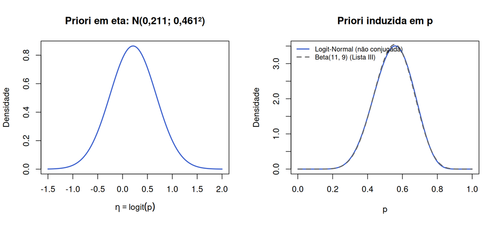

```r
# Densidade da Logit-Normal na escala de p (mudança de variável: |d eta / dp| = 1 / (p(1-p)))
d_logitnorm <- function(p, mu, s) dnorm(qlogis(p), mu, s) / (p * (1 - p))

par(mfrow = c(1, 2))
curve(dnorm(x, mu0, sigma0), from = -1.5, to = 2, lwd = 2, col = "royalblue3",
      xlab = expression(eta == logit(p)), ylab = "Densidade", main = "Priori em eta: N(0,211; 0,461²)")
curve(d_logitnorm(x, mu0, sigma0), from = 0.001, to = 0.999, n = 500, lwd = 2, col = "royalblue3",
      xlab = "p", ylab = "Densidade", main = "Priori induzida em p")
curve(dbeta(x, 11, 9), add = TRUE, lwd = 2, lty = 2, col = "gray40")
legend("topleft", legend = c("Logit-Normal (não conjugada)", "Beta(11, 9) (Lista III)"),
       col = c("royalblue3", "gray40"), lty = c(1, 2), lwd = 2, bty = "n", cex = 0.8)
```

```r
par(mfrow = c(1, 1))
```

O gráfico da direita mostra que a priori induzida em $p$ é quase idêntica à Beta(11, 9) da Lista III. Ou seja, mantive a mesma “crença” a priori, mudando apenas a forma funcional, que agora é não conjugada.

### Resposta 10.b) Formulação do modelo no Stan

O modelo completo é:

$$Y_i \mid \eta \sim \text{Binomial}\left(50,\; p = \frac{e^\eta}{1 + e^\eta}\right), \quad i = 1, \dots, 1000$$

$$\eta \sim N(0,2111;\; 0,4612^2)$$

No Stan, a função `binomial_logit` recebe diretamente o $\eta$ (escala logit), o que é numericamente mais estável. O $p$ é calculado como quantidade transformada.

```r
modelo10_code <- "
data {
  int<lower=1> n;                    // número de indivíduos
  int<lower=1> m;                    // número de locos no painel
  array[n] int<lower=0, upper=m> y;  // locos em homozigose por indivíduo
  real mu0;                          // média da priori de eta
  real<lower=0> sigma0;              // desvio-padrão da priori de eta
}
parameters {
  real eta;                          // logit(p)
}
transformed parameters {
  real<lower=0, upper=1> p = inv_logit(eta);
}
model {
  // Priori não conjugada: logit(p) ~ Normal
  eta ~ normal(mu0, sigma0);
  // Verossimilhança Binomial na escala logit
  y ~ binomial_logit(m, eta);
}
"

modelo10 <- stan_model(model_code = modelo10_code)
```

### Resposta 10.c) Iterações, warm-up e thinning

```r
n_iter10 <- 11000
n_warmup10 <- 1000
n_thin10 <- 1
inits10 <- list(list(eta = -2), list(eta = 2))

fit10 <- sampling(
  object = modelo10,
  data = list(n = N_sim, m = n_par, y = amostra_sim, mu0 = mu0, sigma0 = sigma0),
  chains = 2, iter = n_iter10, warmup = n_warmup10, thin = n_thin10,
  init = inits10, seed = 1234, refresh = 0
)

mcmc10 <- As.mcmc.list(fit10, pars = c("eta", "p"))

print(fit10, pars = c("eta", "p"), probs = c(0.025, 0.5, 0.975), digits = 4)
Inference for Stan model: anon_model.
2 chains, each with iter=11000; warmup=1000; thin=1;
post-warmup draws per chain=10000, total post-warmup draws=20000.

      mean se_mean     sd   2.5%    50%  97.5% n_eff   Rhat
eta 0.4205   1e-04 0.0092 0.4024 0.4205 0.4385  7613 1.0001
p   0.6036   0e+00 0.0022 0.5993 0.6036 0.6079  7614 1.0001

Samples were drawn using NUTS(diag_e) at Sat Nov 21 12:08:33 2026.
For each parameter, n_eff is a crude measure of effective sample size,
and Rhat is the potential scale reduction factor on split chains (at
convergence, Rhat=1).
```

- **Iterações totais:** 11.000 por cadeia (2 cadeias, 22.000 no total);
- **Warm-up:** 1.000 por cadeia;
- **Thinning:** 1 (sem thinning);
- **Amostras finais:** $(11.000 - 1.000) \times 2 =$ 20.000.

Justificativa: tal qual no exercício 9, o modelo tem um único parâmetro e a posteriori é unimodal. Como $n \times m = 50.000$ ensaios, ela é muito concentrada, mas o NUTS adapta o tamanho do passo durante o warm-up, e 1.000 iterações são suficientes para isso e para sair dos valores iniciais. Mantive as mesmas 10.000 iterações pós-warm-up por cadeia do exercício 9, pensando no diagnóstico de Raftery-Lewis. Não usei thinning porque a autocorrelação é baixa (item g).

### Resposta 10.d) Valores iniciais

| Cadeia | $\eta$ inicial | $p$ inicial correspondente |
| --- | --- | --- |
| 1 | -2 | $\frac{e^{-2}}{1 + e^{-2}} \approx 0,119$ |
| 2 | 2 | $\frac{e^{2}}{1 + e^{2}} \approx 0,881$ |

Escolhi valores bem afastados e em lados opostos de $\hat{p} \approx 0,60$: um representando uma população quase sem homozigose e o outro, uma população quase totalmente endogâmica.

### Resposta 10.e) e 10.f) Trace plots

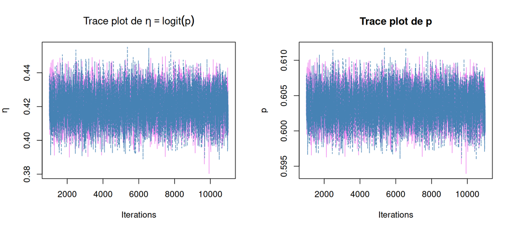

```r
par(mfrow = c(1, 2))
coda::traceplot(mcmc10[, "eta"], col = c("violet", "steelblue"),
                main = expression(paste("Trace plot de ", eta == logit(p))), ylab = expression(eta))
coda::traceplot(mcmc10[, "p"], col = c("violet", "steelblue"),
                main = "Trace plot de p", ylab = "p")
```

```r
par(mfrow = c(1, 1))
```

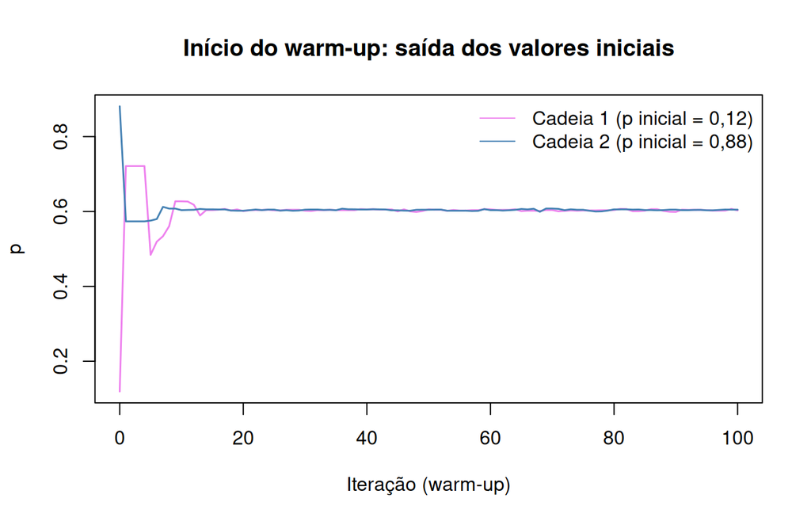

```r
arr10 <- rstan::extract(fit10, pars = "p", permuted = FALSE, inc_warmup = TRUE)
# Valor inicial incluído como iteração 0 (p = inv_logit(-2) e inv_logit(2))
cadeias10 <- rbind(plogis(c(-2, 2)), arr10[1:100, , 1])
matplot(0:100, cadeias10, type = "l", lty = 1, lwd = 1.5, col = c("violet", "steelblue"),
        xlab = "Iteração (warm-up)", ylab = "p", main = "Início do warm-up: saída dos valores iniciais")
legend("topright", legend = c("Cadeia 1 (p inicial = 0,12)", "Cadeia 2 (p inicial = 0,88)"),
       col = c("violet", "steelblue"), lty = 1, bty = "n")
```

No gráfico do warm-up, as duas cadeias saem de $p \approx 0,12$ e $p \approx 0,88$ e chegam em $p \approx 0,60$ em poucas iterações, mostrando que a informação dos dados é muito forte. Depois do warm-up:

- **Estabilidade:** as cadeias oscilam em torno de $p \approx$ 0.6036, sem tendência;
- **Mistura:** as duas cadeias se sobrepõem totalmente, sem trechos parados;
- **Exploração:** percorrem toda a amplitude da posteriori (que é bem estreita, da ordem de ± 0,004) repetidas vezes.

Os trace plots de $\eta$ e $p$ têm o mesmo formato, pois a transformação logit é monótona e, num intervalo tão estreito, praticamente linear.

### Resposta 10.g) Autocorrelação

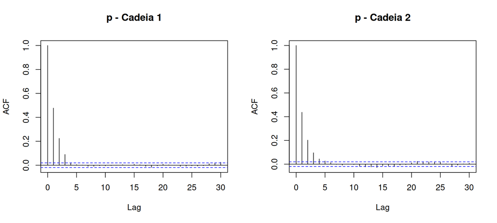

```r
par(mfrow = c(1, 2))
acf(as.numeric(mcmc10[[1]][, "p"]), lag.max = 30, main = "p - Cadeia 1")
acf(as.numeric(mcmc10[[2]][, "p"]), lag.max = 30, main = "p - Cadeia 2")
```

```r
par(mfrow = c(1, 1))
```

```r
autocorr.diag(mcmc10, lags = c(1, 2, 5, 10))
                eta            p
Lag 1   0.457066604  0.457065623
Lag 2   0.213060159  0.213034747
Lag 5   0.015635291  0.015621909
Lag 10 -0.003993339 -0.003978581
```

A autocorrelação no lag 1 é moderada (≈ 0.46) e cai para valores próximos de zero já nos primeiros lags, ficando dentro das bandas de significância. A dependência entre as amostras é fraca e de curta duração, então não foi preciso thinning. Todavia, poderia também ser tentado um thin = 5.

### Resposta 10.h) Diagnósticos de convergência

```r
sp10 <- get_sampler_params(fit10, inc_warmup = FALSE)
cat("--- R-hat (Stan):", round(summary(fit10, pars = c("eta", "p"))$summary[, "Rhat"], 4), "\n")
--- R-hat (Stan): 1.0001 1.0001
cat("--- Divergências:", sum(sapply(sp10, function(x) sum(x[, "divergent__"]))), "\n")
--- Divergências: 0
cat("--- E-BFMI:", round(get_bfmi(fit10), 3), "\n\n")
--- E-BFMI: 1.2 1.253

cat("--- Gelman-Rubin\n");         print(gelman.diag(mcmc10))
--- Gelman-Rubin
Potential scale reduction factors:

    Point est. Upper C.I.
eta          1          1
p            1          1

Multivariate psrf

1
cat("--- Geweke (escores Z)\n");   print(sapply(geweke.diag(mcmc10), function(g) g$z))
--- Geweke (escores Z)
         [,1]      [,2]
eta 0.8173929 -1.444059
p   0.8161384 -1.443659
cat("\n--- Heidelberger-Welch\n"); print(heidel.diag(mcmc10))

--- Heidelberger-Welch
[[1]]

    Stationarity start     p-value
    test         iteration
eta passed       1         0.924
p   passed       1         0.924

    Halfwidth Mean  Halfwidth
    test
eta passed    0.421 2.87e-04
p   passed    0.604 6.87e-05

[[2]]

    Stationarity start     p-value
    test         iteration
eta passed       1         0.116
p   passed       1         0.116

    Halfwidth Mean  Halfwidth
    test
eta passed    0.420 2.87e-04
p   passed    0.604 6.88e-05
cat("--- Raftery-Lewis\n");        print(raftery.diag(mcmc10))
--- Raftery-Lewis
[[1]]

Quantile (q) = 0.025
Accuracy (r) = +/- 0.005
Probability (s) = 0.95

     Burn-in  Total Lower bound  Dependence
     (M)      (N)   (Nmin)       factor (I)
 eta 4        5210  3746         1.39
 p   4        5210  3746         1.39


[[2]]

Quantile (q) = 0.025
Accuracy (r) = +/- 0.005
Probability (s) = 0.95

     Burn-in  Total Lower bound  Dependence
     (M)      (N)   (Nmin)       factor (I)
 eta 4        5210  3746         1.39
 p   4        5210  3746         1.39
```

- **Gelman-Rubin:** $\hat{R} =$ 1 para $p$ (limite superior ≈ 1), as duas cadeias convergiram para a mesma distribuição mesmo partindo de extremos opostos;
- **Geweke:** todos os escores Z dentro de $(-1,96;\; 1,96)$, sem diferença entre o início e o fim das cadeias;
- **Heidelberger-Welch:** todas as cadeias passaram nos testes de estacionariedade e de meia-amplitude;
- **Raftery-Lewis:** fator de dependência baixo (< 5) e número de iterações sugerido (N) inferior às 10.000 utilizadas por cadeia;
- **Diagnósticos do NUTS:** zero divergências e E-BFMI > 0,3 nas duas cadeias.

Há evidência de convergência, e as amostras podem ser usadas para inferência.

### Resposta 10.i) Tamanho Efetivo da Amostra (ESS)

```r
n_total10 <- 2 * (n_iter10 - n_warmup10)
ess10 <- effectiveSize(mcmc10)
mcse10 <- apply(as.matrix(mcmc10), 2, sd) / sqrt(ess10)

kable(data.frame(
  Parametro = names(ess10),
  N_total = n_total10,
  ESS = ess10,
  ESS_relativo = ess10 / n_total10,
  MCSE = mcse10
), digits = 6, row.names = FALSE)
```

| Parametro | N_total | ESS | ESS_relativo | MCSE |
| --- | --- | --- | --- | --- |
| eta | 20000 | 7796.555 | 0.389828 | 0.000104 |
| p | 20000 | 7797.067 | 0.389853 | 0.000025 |

O ESS de $p$ foi de 7797 em 20.000 valores (≈ 39%), o que equivale a milhares de amostras independentes. O MCSE da média de $p$ ficou na ordem de $10^{-5}$, desprezível frente ao desvio-padrão da posteriori. As estimativas têm precisão numérica mais do que suficiente.

### Resposta 10.k) Estimativas a posteriori

```r
p_post <- as.matrix(mcmc10)[, "p"]
eta_post <- as.matrix(mcmc10)[, "eta"]

res10_p <- resumo_post(p_post)
res10_eta <- resumo_post(eta_post)

# Comparação com a posteriori conjugada da Lista III (Beta(11, 9)) com os mesmos dados
a10_conj <- soma_y10 + 11
b10_conj <- N_sim * n_par - soma_y10 + 9
exato10 <- c(Media = a10_conj / (a10_conj + b10_conj),
             Mediana = qbeta(0.5, a10_conj, b10_conj),
             Variancia = a10_conj * b10_conj / ((a10_conj + b10_conj)^2 * (a10_conj + b10_conj + 1)),
             CV_perc = NA, IC_inf = qbeta(0.025, a10_conj, b10_conj),
             IC_sup = qbeta(0.975, a10_conj, b10_conj),
             HPD_inf = hdi(qbeta, 0.95, shape1 = a10_conj, shape2 = b10_conj)[1],
             HPD_sup = hdi(qbeta, 0.95, shape1 = a10_conj, shape2 = b10_conj)[2])
exato10["CV_perc"] <- 100 * sqrt(exato10["Variancia"]) / exato10["Media"]

tabela10 <- rbind("p (MCMC - Logit-Normal)" = res10_p,
                  "p (exato - conjugada Beta(11,9))" = exato10,
                  "eta = logit(p) (MCMC)" = res10_eta)
kable(tabela10, digits = 6)
```

|  | Media | Mediana | Variancia | CV_perc | IC_inf | IC_sup | HPD_inf | HPD_sup |
| --- | --- | --- | --- | --- | --- | --- | --- | --- |
| p (MCMC - Logit-Normal) | 0.603589 | 0.603596 | 5.0e-06 | 0.362840 | 0.599262 | 0.607899 | 0.599227 | 0.607840 |
| p (exato - conjugada Beta(11,9)) | 0.603559 | 0.603560 | 5.0e-06 | 0.362371 | 0.599268 | 0.607841 | 0.599271 | 0.607844 |
| eta = logit(p) (MCMC) | 0.420451 | 0.420471 | 8.4e-05 | 2.176980 | 0.402392 | 0.438490 | 0.402245 | 0.438240 |

Para o parâmetro de interesse $p$ (probabilidade de homozigose por loco):

| Medida | Valor |
| --- | --- |
| Média | 0.60359 |
| Mediana | 0.6036 |
| Variância | 4.796e-06 |
| Coeficiente de variação | 0.363% |
| IC 95% | [0.5993; 0.6079] |
| HPD 95% | [0.5992; 0.6078] |

Os resultados praticamente coincidem com os da posteriori conjugada Beta, o que era esperado, pois as duas prioris carregam a mesma informação e os 50.000 ensaios dominam a posteriori.

### Resposta 10.j) Distribuições marginais a posteriori

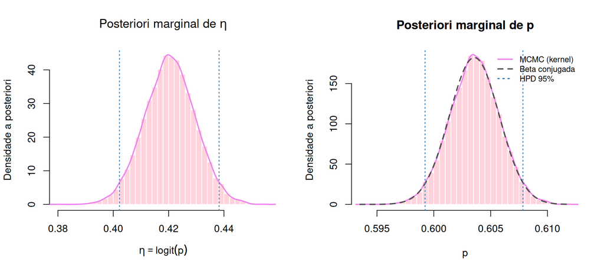

```r
par(mfrow = c(1, 2))

hist(eta_post, breaks = 50, probability = TRUE, col = adjustcolor("pink", alpha.f = 0.7),
     border = "white", main = expression(paste("Posteriori marginal de ", eta)),
     xlab = expression(eta == logit(p)), ylab = "Densidade a posteriori")
lines(density(eta_post), lwd = 2, col = "violet")
abline(v = res10_eta[c("HPD_inf", "HPD_sup")], lty = 3, col = "steelblue", lwd = 1.5)

hist(p_post, breaks = 50, probability = TRUE, col = adjustcolor("pink", alpha.f = 0.7),
     border = "white", main = "Posteriori marginal de p",
     xlab = "p", ylab = "Densidade a posteriori")
lines(density(p_post), lwd = 2, col = "violet")
curve(dbeta(x, a10_conj, b10_conj), add = TRUE, lwd = 2, lty = 2, col = "gray30")
abline(v = res10_p[c("HPD_inf", "HPD_sup")], lty = 3, col = "steelblue", lwd = 1.5)
legend("topright", legend = c("MCMC (kernel)", "Beta conjugada", "HPD 95%"),
       col = c("violet", "gray30", "steelblue"), lty = c(1, 2, 3), lwd = 2, bty = "n", cex = 0.8)
```

```r
par(mfrow = c(1, 1))
```

### Resposta 10.k) Forma das distribuições marginais

As duas marginais são **simétricas**, com formato de sino (praticamente Normais):

- média e mediana praticamente iguais: 0.60359 e 0.6036 para $p$;
- IC de caudas iguais e HPD praticamente coincidem (diferem apenas na quarta casa decimal);
- o histograma acompanha bem a curva da Beta conjugada.

Isso acontece porque, com 50.000 ensaios, a posteriori fica muito concentrada e, pelo comportamento assintótico (a posteriori se aproxima de uma Normal quando $n$ é grande), qualquer assimetria desaparece. Em princípio, a Logit-Normal seria assimétrica na escala de $p$ quando concentrada perto de 0 ou de 1, mas aqui a posteriori está concentrada em uma faixa muito estreita em torno de 0,60, onde a transformação logit é quase linear.

### Resposta 10.l) Por que a priori não conjugada dificulta a solução analítica

Escrevendo a posteriori de $\eta$ passo a passo:

**Verossimilhança** (com $p = \frac{e^\eta}{1 + e^\eta}$ e $1 - p = \frac{1}{1 + e^\eta}$):

$$L(\eta \mid y) \propto p^{\sum y_i}(1 - p)^{nm - \sum y_i} = \left(\frac{e^\eta}{1 + e^\eta}\right)^{\sum y_i}\left(\frac{1}{1 + e^\eta}\right)^{nm - \sum y_i}$$

$$L(\eta \mid y) \propto \frac{e^{\eta \sum y_i}}{(1 + e^\eta)^{nm}}$$

**Priori:**

$$\pi(\eta) \propto \exp\left\{-\frac{(\eta - \mu_0)^2}{2\sigma_0^2}\right\}$$

**Posteriori:**

$$\pi(\eta \mid y) \propto \frac{\exp\left\{\eta\sum y_i - \frac{(\eta - \mu_0)^2}{2\sigma_0^2}\right\}}{(1 + e^\eta)^{nm}}$$

Esse núcleo **não pertence a nenhuma família conhecida**. O termo $(1 + e^\eta)^{-nm}$ não pode ser combinado com o núcleo Normal $e^{-(\eta - \mu_0)^2/2\sigma_0^2}$ para formar uma Normal (nem outra distribuição tabelada). Para ter a posteriori completa, seria preciso calcular a constante de normalização:

$$\pi(y) = \int_{-\infty}^{+\infty} \frac{\exp\left\{\eta\sum y_i - \frac{(\eta - \mu_0)^2}{2\sigma_0^2}\right\}}{(1 + e^\eta)^{nm}}\,d\eta$$

Essa integral **não tem solução analítica**. O mesmo vale para $E(\eta \mid y)$, $V(\eta \mid y)$ e os quantis, que dependem de integrais desse mesmo tipo. Já na Lista III, com a priori Beta, os expoentes de $p$ e $(1-p)$ simplesmente se somavam e a posteriori era uma Beta.

**Por que usar MCMC:** os algoritmos MCMC (Metropolis-Hastings, HMC/NUTS) só precisam da posteriori **a menos de uma constante**, pois $\pi(y)$ se cancela na razão de aceitação. Assim, basta avaliar o numerador acima (no Stan, o log dele) para gerar uma cadeia cuja distribuição estacionária é $\pi(\eta \mid y)$. A partir das amostras, obtemos qualquer quantidade de interesse (média, mediana, variância, intervalos, a distribuição de $p = \text{logit}^{-1}(\eta)$) sem nunca resolver a integral. Além disso, se o modelo fosse ampliado (por exemplo, com efeitos de linhagem e de geração na escala logit), a integração analítica ficaria ainda mais inviável, enquanto o MCMC continuaria funcionando da mesma forma.